# Nigeria Food Consumption

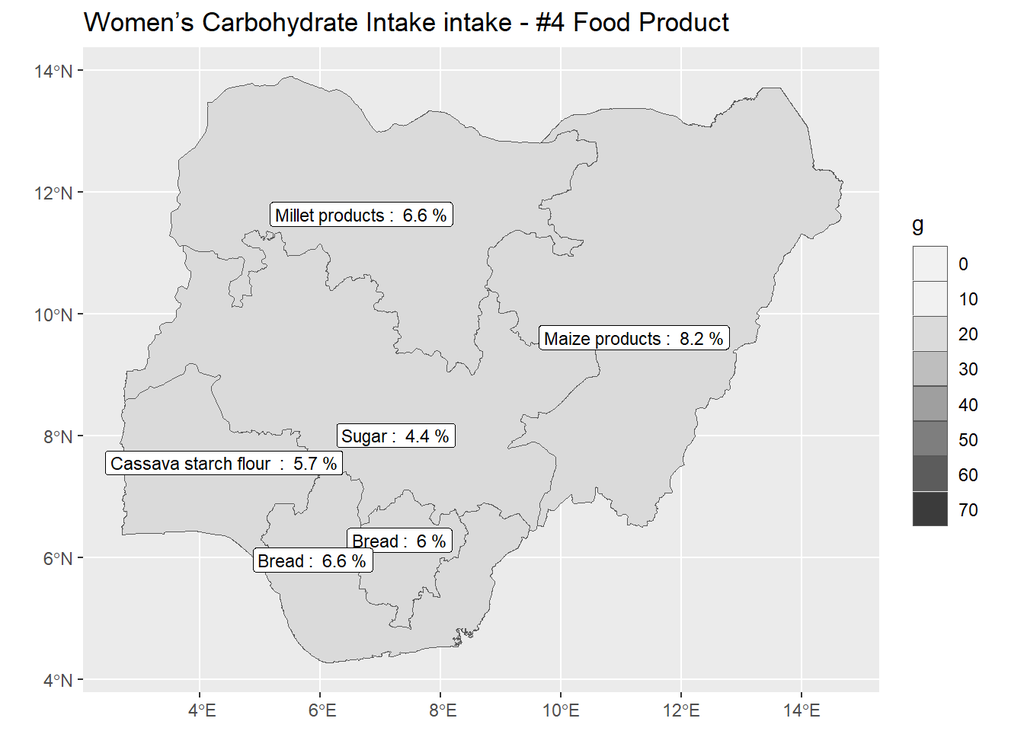

```r
ggplot(vect_gpz_geo_NFCMS_A17) +
  geom_spatvector(aes(fill = SN4_g)) +
  geom_spatvector_label(
    aes(label = paste(SN4_Name, ": ", SN4_pc, "%")),
    position = position_jitter(width = 0.1, height = 1.2, seed = 3),
    size = 3
  ) +
  scale_fill_stepsn(
    n.breaks = 10,
    limits = c(0, 75),
    colours = hcl.colors(palette = "Grays", 10, rev = T),
    guide = "legend",
    na.value = "pink",
    labels = scales::comma
  ) +
  labs(
    title = "Women's Carbohydrate Intake intake - #4 Food Product",
    fill = "g"
  ) +
  theme(
    plot.title = element_markdown(),
    legend.title = element_markdown(),
    axis.title = element_blank()
  )
```

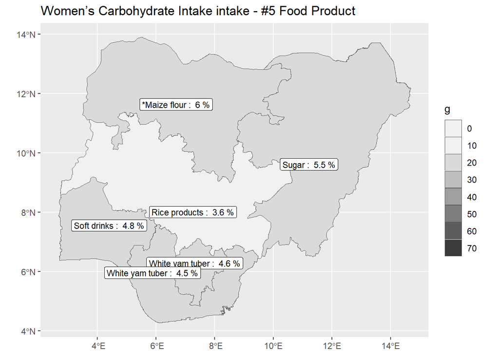

```r
ggplot(vect_gpz_geo_NFCMS_A17) +
  geom_spatvector(aes(fill = SN5_g)) +
  geom_spatvector_label(
    aes(label = paste(SN5_Name, ": ", SN5_pc, "%")),
    position = position_jitter(width = 0.1, height = 1.2, seed = 3),
    size = 3
  ) +
  scale_fill_stepsn(
    n.breaks = 10,
    limits = c(0, 75),
    colours = hcl.colors(palette = "Grays", 10, rev = T),
    guide = "legend",
    na.value = "pink",
    labels = scales::comma
  ) +
  labs(
    title = "Women's Carbohydrate Intake intake - #5 Food Product",
    fill = "g"
  ) +
  theme(
    plot.title = element_markdown(),
    legend.title = element_markdown(),
    axis.title = element_blank()
  )
```

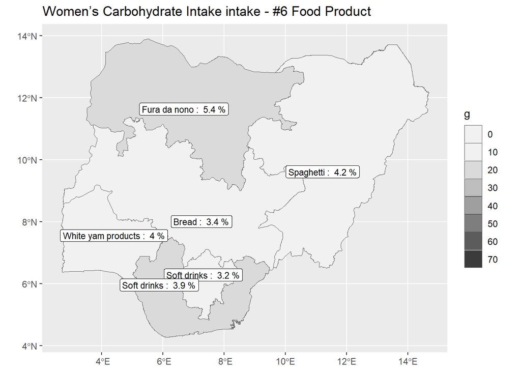

```r
ggplot(vect_gpz_geo_NFCMS_A17) +
  geom_spatvector(aes(fill = SN6_g)) +
  geom_spatvector_label(
    aes(label = paste(SN6_Name, ": ", SN6_pc, "%")),
    position = position_jitter(width = 0.1, height = 1.2, seed = 3),
    size = 3
  ) +
  scale_fill_stepsn(
    n.breaks = 10,
    limits = c(0, 75),
    colours = hcl.colors(palette = "Grays", 10, rev = T),
    guide = "legend",
    na.value = "pink",
    labels = scales::comma
  ) +
  labs(
    title = "Women's Carbohydrate Intake intake - #6 Food Product",
    fill = "g"
  ) +
  theme(
    plot.title = element_markdown(),
    legend.title = element_markdown(),
    axis.title = element_blank()
  )
```

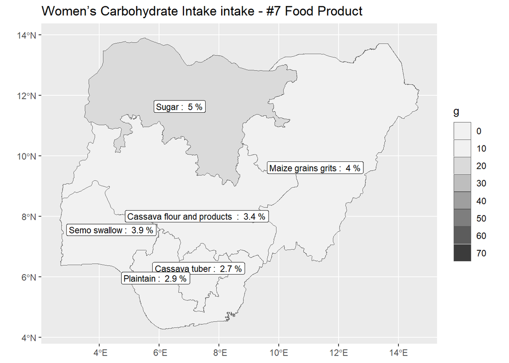

```r
ggplot(vect_gpz_geo_NFCMS_A17) +
  geom_spatvector(aes(fill = SN7_g)) +
  geom_spatvector_label(
    aes(label = paste(SN7_Name, ": ", SN7_pc, "%")),
    position = position_jitter(width = 0.1, height = 1.2, seed = 3),
    size = 3
  ) +
  scale_fill_stepsn(
    n.breaks = 10,
    limits = c(0, 75),
    colours = hcl.colors(palette = "Grays", 10, rev = T),
    guide = "legend",
    na.value = "pink",
    labels = scales::comma
  ) +
  labs(
    title = "Women's Carbohydrate Intake intake - #7 Food Product",
    fill = "g"
  ) +
  theme(
    plot.title = element_markdown(),
    legend.title = element_markdown(),
    axis.title = element_blank()
  )
```

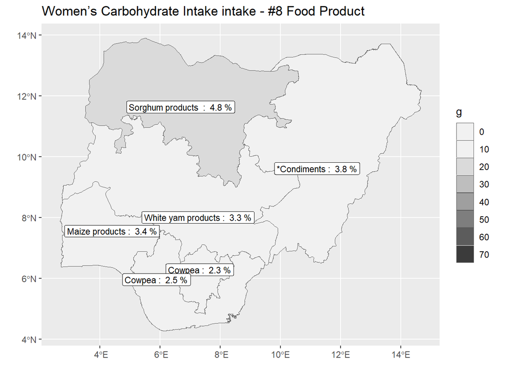

```r
ggplot(vect_gpz_geo_NFCMS_A17) +
  geom_spatvector(aes(fill = SN8_g)) +
  geom_spatvector_label(
    aes(label = paste(SN8_Name, ": ", SN8_pc, "%")),
    position = position_jitter(width = 0.1, height = 1.2, seed = 3),
    size = 3
  ) +
  scale_fill_stepsn(
    n.breaks = 10,
    limits = c(0, 75),
    colours = hcl.colors(palette = "Grays", 10, rev = T),
    guide = "legend",
    na.value = "pink",
    labels = scales::comma
  ) +
  labs(
    title = "Women's Carbohydrate Intake intake - #8 Food Product",
    fill = "g"
  ) +
  theme(
    plot.title = element_markdown(),
    legend.title = element_markdown(),
    axis.title = element_blank()
  )
```

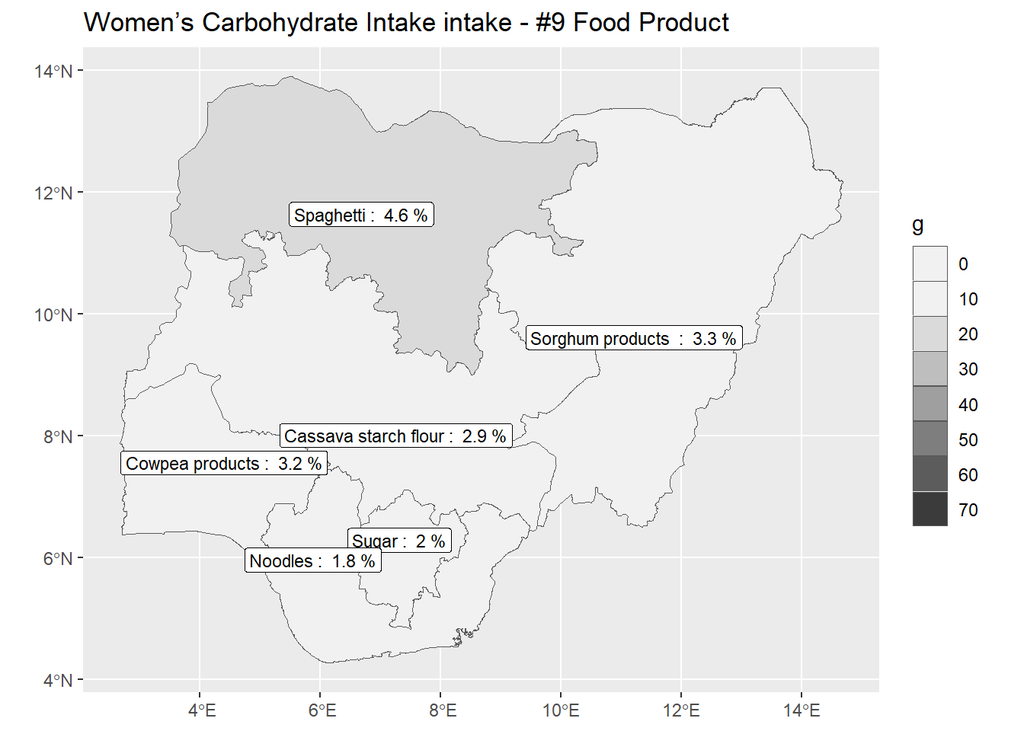

```r
ggplot(vect_gpz_geo_NFCMS_A17) +
  geom_spatvector(aes(fill = SN9_g)) +
  geom_spatvector_label(
    aes(label = paste(SN9_Name, ": ", SN9_pc, "%")),
    position = position_jitter(width = 0.1, height = 1.2, seed = 3),
    size = 3
  ) +
  scale_fill_stepsn(
    n.breaks = 10,
    limits = c(0, 75),
    colours = hcl.colors(palette = "Grays", 10, rev = T),
    guide = "legend",
    na.value = "pink",
    labels = scales::comma
  ) +
  labs(
    title = "Women's Carbohydrate Intake intake - #9 Food Product",
    fill = "g"
  ) +
  theme(
    plot.title = element_markdown(),
    legend.title = element_markdown(),
    axis.title = element_blank()
  )
```

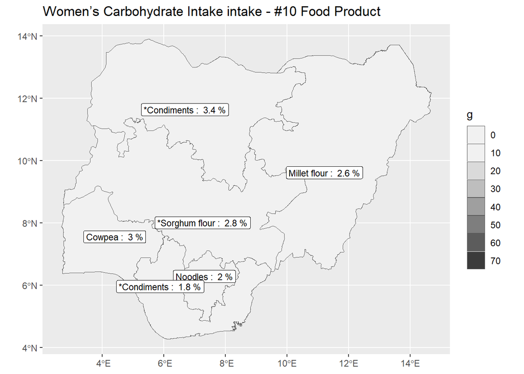

```r
ggplot(vect_gpz_geo_NFCMS_A17) +
  geom_spatvector(aes(fill = SN10_g)) +
  geom_spatvector_label(
    aes(label = paste(SN10_Name, ": ", SN10_pc, "%")),
    position = position_jitter(width = 0.1, height = 1.2, seed = 3),
    size = 3
  ) +
  scale_fill_stepsn(
    n.breaks = 10,
    limits = c(0, 75),
    colours = hcl.colors(palette = "Grays", 10, rev = T),
    guide = "legend",
    na.value = "pink",
    labels = scales::comma
  ) +
  labs(
    title = "Women's Carbohydrate Intake intake - #10 Food Product",
    fill = "g"
  ) +
  theme(
    plot.title = element_markdown(),
    legend.title = element_markdown(),
    axis.title = element_blank()
  )
```

## Carbohydrates

The NFCMS dataset includes information about the consumption of macro-nutrients, and their contribution to energy intake.

### Carbohydrate intake (NFCMS, 2021)

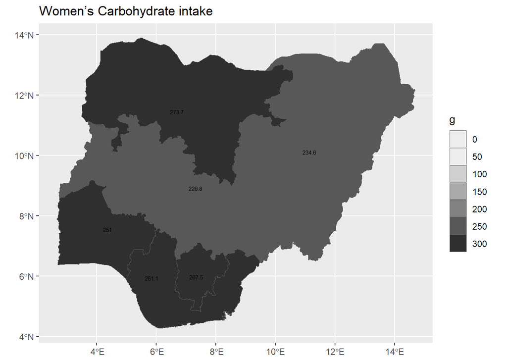

```r
ggplot(vect_gpz_geo_NFCMS) +
  geom_spatvector(aes(fill = CARB_IN_W_63)) +
  geom_spatvector_text(aes(label = CARB_IN_W_63), size = 2) +
  scale_fill_stepsn(
    n.breaks = 10,
    limits = c(0, 300),
    colours = hcl.colors(palette = "Grays", 10, rev = T),
    guide = "legend",
    na.value = "pink",
    labels = scales::comma
  ) +
  labs(title = "Women's Carbohydrate intake", fill = "g") +
  theme(
    plot.title = element_markdown(),
    legend.title = element_markdown(),
    axis.title = element_blank()
  )
```

### Contribution of carbohydrate to total usual energy intake (NFCMS, 2021)

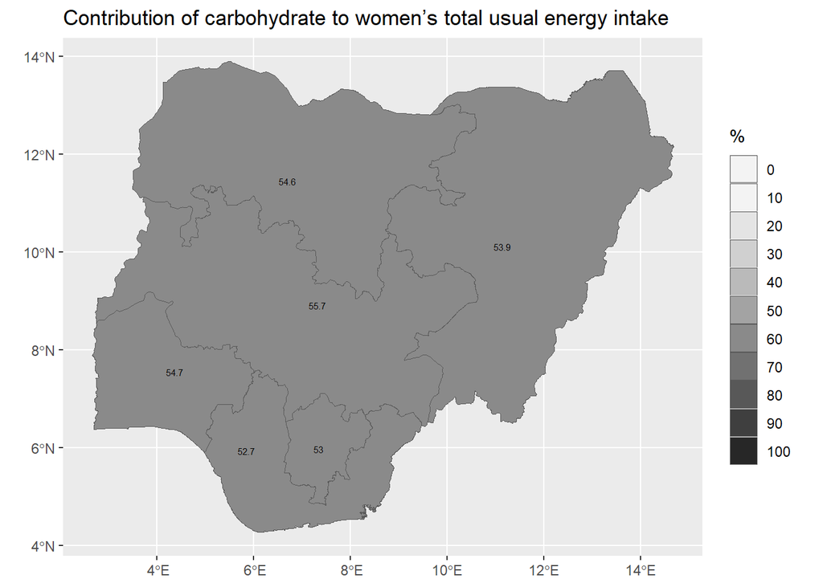

```r
ggplot(vect_gpz_geo_NFCMS) +
  geom_spatvector(aes(fill = CARB_EN_IN_W_65)) +
  geom_spatvector_text(aes(label = CARB_EN_IN_W_65), size = 2) +
  scale_fill_stepsn(
    n.breaks = 10,
    limits = c(0, 100),
    colours = hcl.colors(palette = "Grays", 10, rev = T),
    guide = "legend",
    na.value = "pink",
    labels = scales::comma
  ) +
  labs(title = " Contribution of carbohydrate to women's total usual energy intake", fill = "%") +
  theme(
    plot.title = element_markdown(),
    legend.title = element_markdown(),
    axis.title = element_blank()
  )
```

### Grains, white roots and tubers, and plantains (GHS, 2024)

The GHS does not extract the macro-nutrient data from the food products consumed. Instead the dataset combines food products into major food groups.

These food groups are not directly comparable to the macro-nutrients in the NFCMS, but it is useful to compare food groups that are important sources of the macro-nutrients. For instance, grains, roots, tubers and plantains are major sources of carbohydrates.

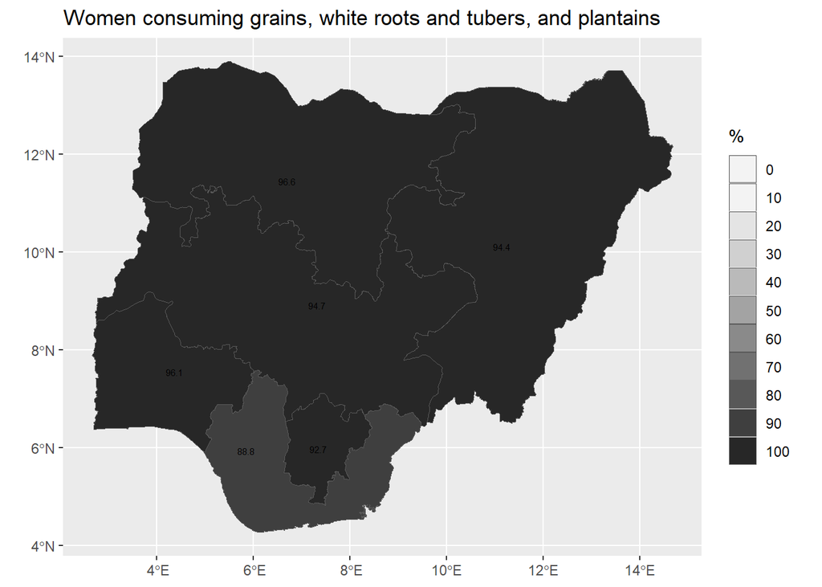

```r
ggplot(vect_gpz_geo_GHS) +
  geom_spatvector(aes(fill = gr_rtb)) +
  geom_spatvector_text(aes(label = gr_rtb), size = 2) +
  scale_fill_stepsn(
    n.breaks = 10,
    limits = c(0, 100),
    colours = hcl.colors(palette = "Grays", 10, rev = T),
    guide = "legend",
    na.value = "pink",
    labels = scales::comma
  ) +
  labs(title = "Women consuming grains, white roots and tubers, and plantains", fill = "%") +
  theme(
    plot.title = element_markdown(),
    legend.title = element_markdown(),
    axis.title = element_blank()
  )
```

### Conclusion

The NFCMS data show the amount of carbohydrates consumed. There are not huge differences across zones in the amounts consumed. Similarly, the contribution of carbohydrates to women’s energy intake varies little among the zones - with carbohydrate providing just over half of all energy.

The GHS from 2023/24 shows that most women regularly consume carbohydrate rich grains, roots, tubers and plantains. The only zone where this percentage is below 90% is South South.

## Plant Proteins

### Plant Protein intake (NFCMS, 2021)

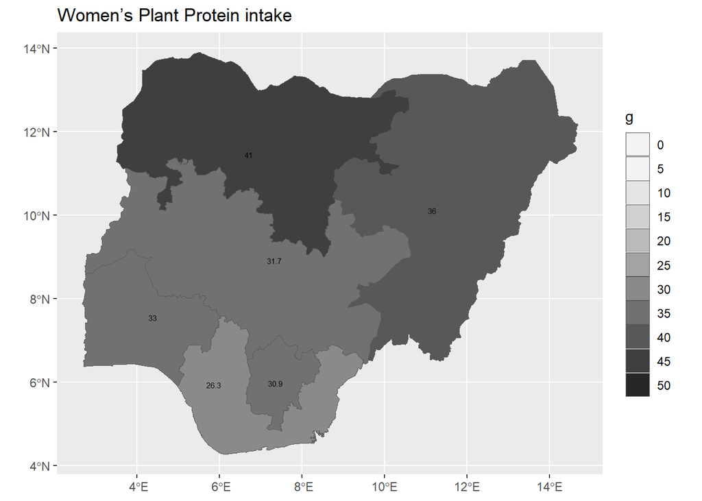

```r
ggplot(vect_gpz_geo_NFCMS) +
  geom_spatvector(aes(fill = PL_PROT_IN_W_48)) +
  geom_spatvector_text(aes(label = PL_PROT_IN_W_48), size = 2) +
  scale_fill_stepsn(
    n.breaks = 10,
    limits = c(0, 50),
    colours = hcl.colors(palette = "Grays", 10, rev = T),
    guide = "legend",
    na.value = "pink",
    labels = scales::comma
  ) +
  labs(title = "Women's Plant Protein intake", fill = "g") +
  theme(
    plot.title = element_markdown(),
    legend.title = element_markdown(),
    axis.title = element_blank()
  )
```

### Contribution of plant proteins to total usual energy intake (NFCMS, 2021)

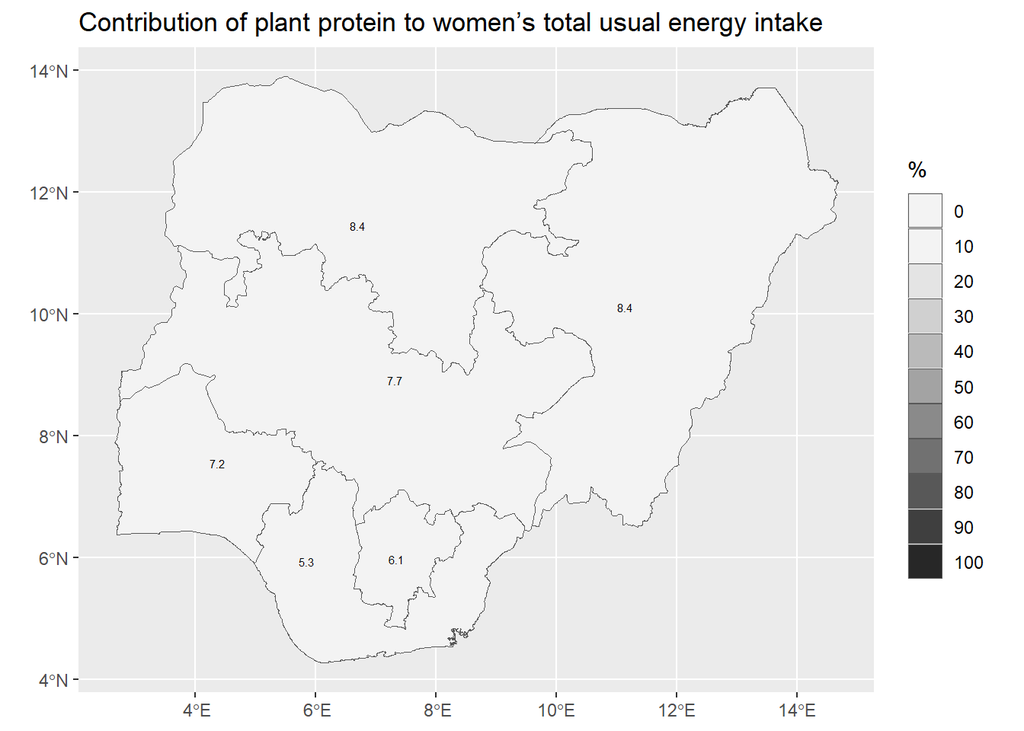

```r
ggplot(vect_gpz_geo_NFCMS) +
  geom_spatvector(aes(fill = PL_PROT_EN_IN_W_57)) +
  geom_spatvector_text(aes(label = PL_PROT_EN_IN_W_57), size = 2) +
  scale_fill_stepsn(
    n.breaks = 10,
    limits = c(0, 100),
    colours = hcl.colors(palette = "Grays", 10, rev = T),
    guide = "legend",
    na.value = "pink",
    labels = scales::comma
  ) +
  labs(title = " Contribution of plant protein to women's total usual energy intake", fill = "%") +
  theme(
    plot.title = element_markdown(),
    legend.title = element_markdown(),
    axis.title = element_blank()
  )
```

### Pulses (GHS, 2024)

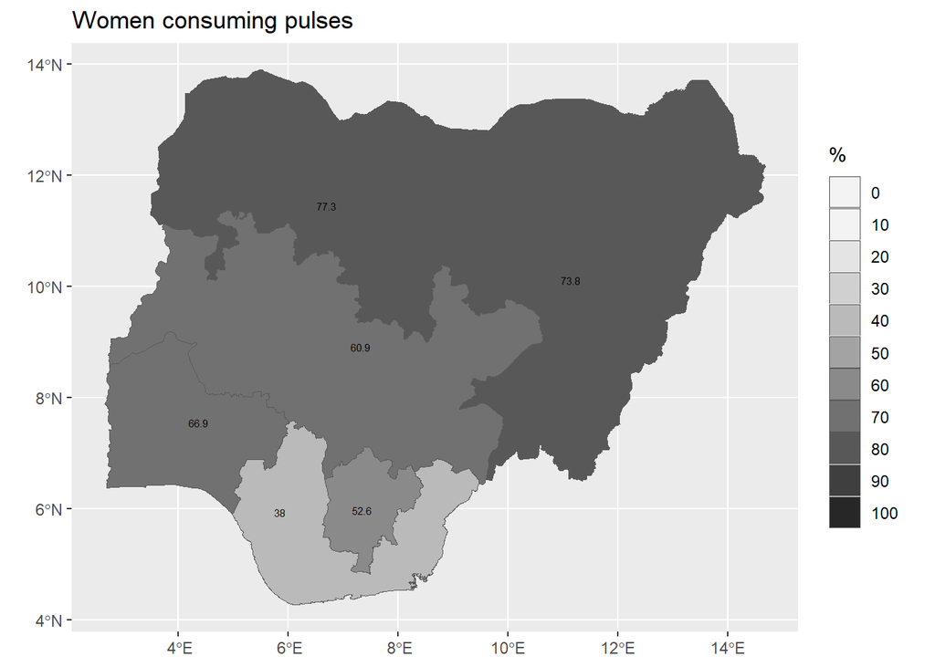

```r
ggplot(vect_gpz_geo_GHS) +
  geom_spatvector(aes(fill = pulses)) +
  geom_spatvector_text(aes(label = pulses), size = 2) +
  scale_fill_stepsn(
    n.breaks = 10,
    limits = c(0, 100),
    colours = hcl.colors(palette = "Grays", 10, rev = T),
    guide = "legend",
    na.value = "pink",
    labels = scales::comma
  ) +
  labs(title = "Women consuming pulses", fill = "%") +
  theme(
    plot.title = element_markdown(),
    legend.title = element_markdown(),
    axis.title = element_blank()
  )
```

### Conclusion

There is no direct comparison in the GHS dataset, but the group of food products most often associated with plant protein is pulses. The proportion of women consuming pulses in the GHS shows a similar pattern to the amount of plant protein consumed in 2021, with women in North East and North West zones the most regular consumers.

## Animal Proteins

### Animal Protein intake (NFCMS, 2021)

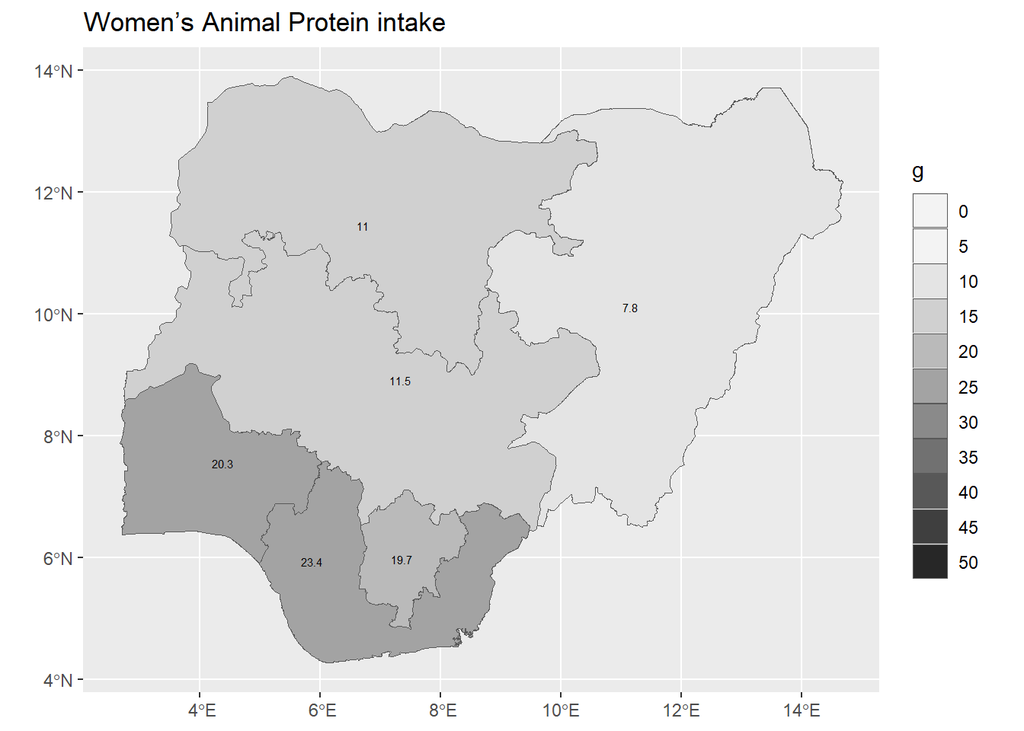

```r
ggplot(vect_gpz_geo_NFCMS) +
  geom_spatvector(aes(fill = AN_PROT_IN_W_47)) +
  geom_spatvector_text(aes(label = AN_PROT_IN_W_47), size = 2) +
  scale_fill_stepsn(
    n.breaks = 10,
    limits = c(0, 50),
    colours = hcl.colors(palette = "Grays", 10, rev = T),
    guide = "legend",
    na.value = "pink",
    labels = scales::comma
  ) +
  labs(title = "Women's Animal Protein intake", fill = "g") +
  theme(
    plot.title = element_markdown(),
    legend.title = element_markdown(),
    axis.title = element_blank()
  )
```

### Contribution of animal proteins to total usual energy intake (NFCMS, 2021)

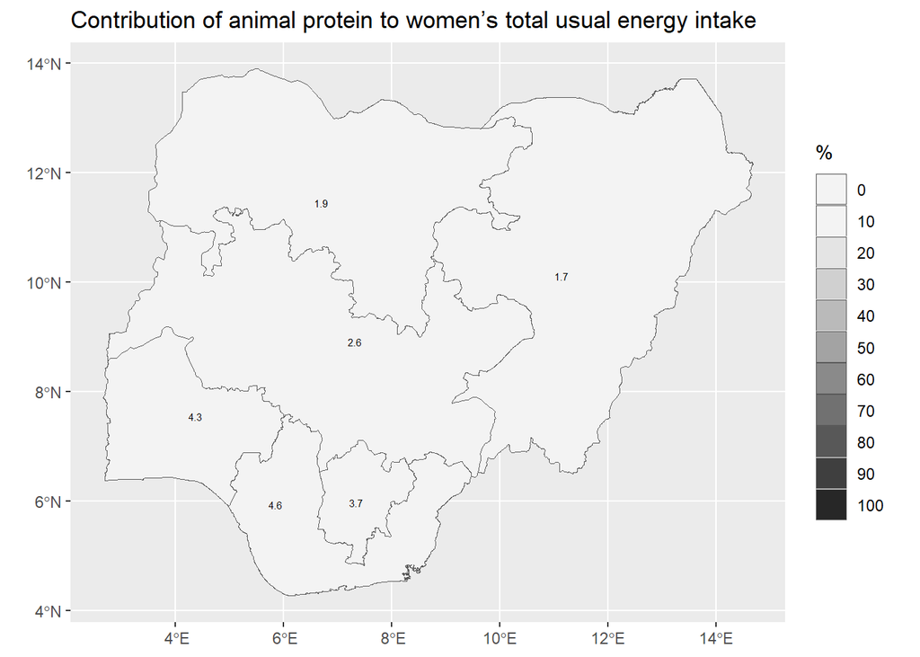

```r
ggplot(vect_gpz_geo_NFCMS) +
  geom_spatvector(aes(fill = AN_PROT_EN_IN_W_55)) +
  geom_spatvector_text(aes(label = AN_PROT_EN_IN_W_55), size = 2) +
  scale_fill_stepsn(
    n.breaks = 10,
    limits = c(0, 100),
    colours = hcl.colors(palette = "Grays", 10, rev = T),
    guide = "legend",
    na.value = "pink",
    labels = scales::comma
  ) +
  labs(title = " Contribution of animal protein to women's total usual energy intake", fill = "%") +
  theme(
    plot.title = element_markdown(),
    legend.title = element_markdown(),
    axis.title = element_blank()
  )
```

### Dairy (GHS, 2024)

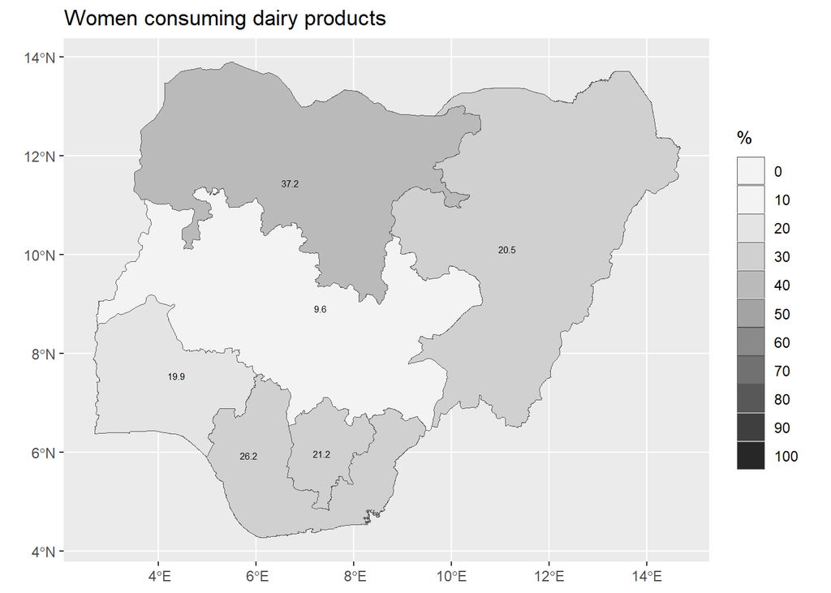

```r
ggplot(vect_gpz_geo_GHS) +
  geom_spatvector(aes(fill = dairy)) +
  geom_spatvector_text(aes(label = dairy), size = 2) +
  scale_fill_stepsn(
    n.breaks = 10,
    limits = c(0, 100),
    colours = hcl.colors(palette = "Grays", 10, rev = T),
    guide = "legend",
    na.value = "pink",
    labels = scales::comma
  ) +
  labs(title = "Women consuming dairy products", fill = "%") +
  theme(
    plot.title = element_markdown(),
    legend.title = element_markdown(),
    axis.title = element_blank()
  )
```

### Meat, poultry, fish (GHS, 2024)

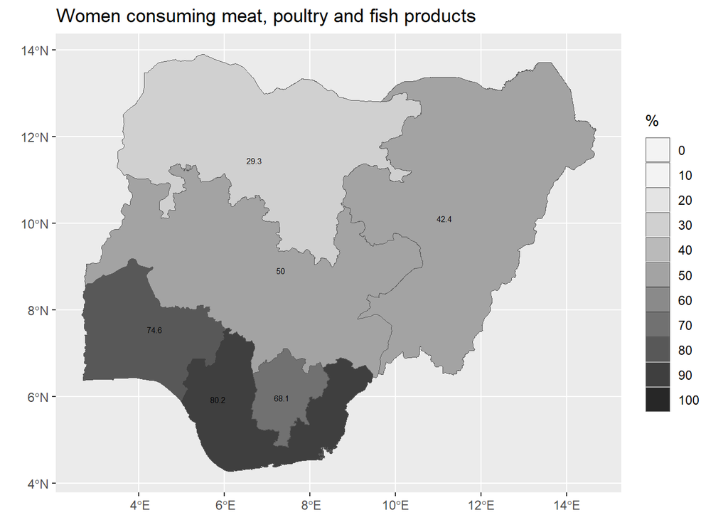

```r
ggplot(vect_gpz_geo_GHS) +
  geom_spatvector(aes(fill = meat_fish)) +
  geom_spatvector_text(aes(label = meat_fish), size = 2) +
  scale_fill_stepsn(
    n.breaks = 10,
    limits = c(0, 100),
    colours = hcl.colors(palette = "Grays", 10, rev = T),
    guide = "legend",
    na.value = "pink",
    labels = scales::comma
  ) +
  labs(title = "Women consuming meat, poultry and fish products", fill = "%") +
  theme(
    plot.title = element_markdown(),
    legend.title = element_markdown(),
    axis.title = element_blank()
  )
```

### Eggs (GHS, 2024)

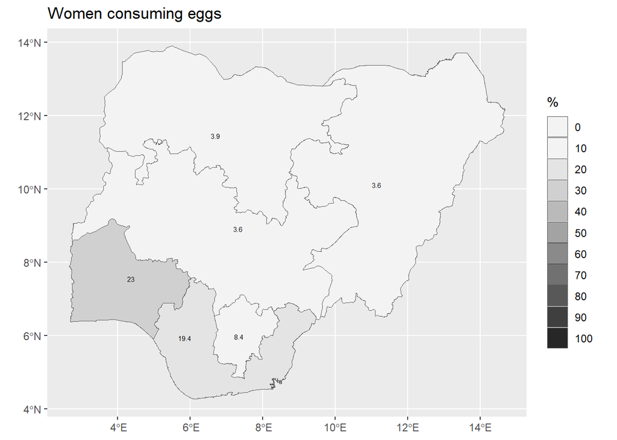

```r
ggplot(vect_gpz_geo_GHS) +
  geom_spatvector(aes(fill = eggs)) +
  geom_spatvector_text(aes(label = eggs), size = 2) +
  scale_fill_stepsn(
    n.breaks = 10,
    limits = c(0, 100),
    colours = hcl.colors(palette = "Grays", 10, rev = T),
    guide = "legend",
    na.value = "pink",
    labels = scales::comma
  ) +
  labs(title = "Women consuming eggs", fill = "%") +
  theme(
    plot.title = element_markdown(),
    legend.title = element_markdown(),
    axis.title = element_blank()
  )
```

### Conclusion

Animal proteins are less relevant for crop bio fortification, but they are useful to consider because they are often nutrient dense, an alternative to plant based food products (especially pulses), and many consumers aspire to consume more of these products. The consumption of these products therefore needs to be monitored to see if the Nigerian diet is evolving over time to include more animal products.

Animal protein intake in the 2021 NFCMS is in general lower than plant protein, but there are regional differences. Animal protein intake in South South is almost as high as plant protein intake, whereas in North East the animal protein intake is only 1/4 of the plant protein intake.

The contribution of animal protein to overall usual energy intake follows the same pattern with the South South and South West zones showing the highest contribution.

Women in the North West are the most common consumers of dairy products, while the neighbouring zone of North Central has the lowest percentage of women consuming milk or milk products.

A majority of women consume meat, poultry or fish in the southern zones, while the North West zone has the lowest proportion - perhaps dairy products are a more sustainable source of products for extensive livestock owners.

Eggs have very low consumption throughout Nigeria. The only two zones where these are consumed by more than 15% of women are in South West and South South.

In general the data from the two surveys are complementary and display the same spatial patterns; the NFCMS shows the overall contribution of animal protein to women’s diets, while the GHS shows the prevalence of consumption of animal food products.

# Micro-nutrient Intake

There are no micro-nutrient intake data in the GHS dataset.

## Total Calcium intake

The NFCMS provides a list of the 10 food products that contribute most to Calcium intake for each zone. These data provide context to the macro-nutrient intake for each zone, and provide insights into the food basket composition for each zone.

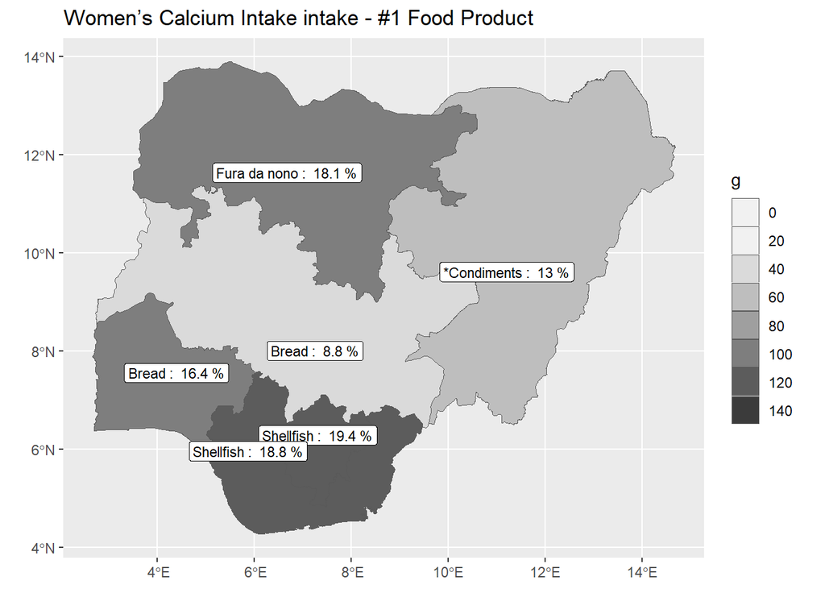

```r
ggplot(vect_gpz_geo_NFCMS_A19) +
  geom_spatvector(aes(fill = SN1_g)) +
  geom_spatvector_label(
    aes(label = paste(SN1_Name, ": ", SN1_pc, "%")),
    position = position_jitter(width = 0.1, height = 1.2, seed = 3),
    size = 3
  ) +
  scale_fill_stepsn(
    n.breaks = 10,
    limits = c(0, 150),
    colours = hcl.colors(palette = "Grays", 10, rev = T),
    guide = "legend",
    na.value = "pink",
    labels = scales::comma
  ) +
  labs(
    title = "Women's Calcium Intake intake - #1 Food Product",
    fill = "g"
  ) +
  theme(
    plot.title = element_markdown(),
    legend.title = element_markdown(),
    axis.title = element_blank()
  )
```

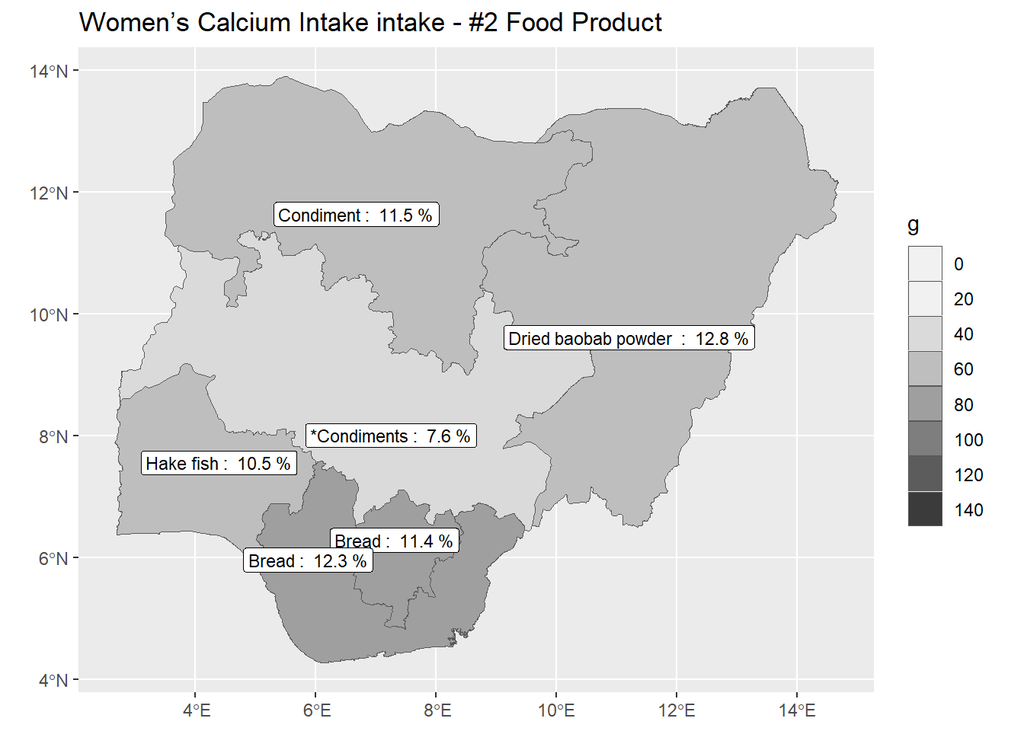

```r
ggplot(vect_gpz_geo_NFCMS_A19) +
  geom_spatvector(aes(fill = SN2_g)) +
  geom_spatvector_label(
    aes(label = paste(SN2_Name, ": ", SN2_pc, "%")),
    position = position_jitter(width = 0.1, height = 1.2, seed = 3),
    size = 3
  ) +
  scale_fill_stepsn(
    n.breaks = 10,
    limits = c(0, 150),
    colours = hcl.colors(palette = "Grays", 10, rev = T),
    guide = "legend",
    na.value = "pink",
    labels = scales::comma
  ) +
  labs(
    title = "Women's Calcium Intake intake - #2 Food Product",
    fill = "g"
  ) +
  theme(
    plot.title = element_markdown(),
    legend.title = element_markdown(),
    axis.title = element_blank()
  )
```

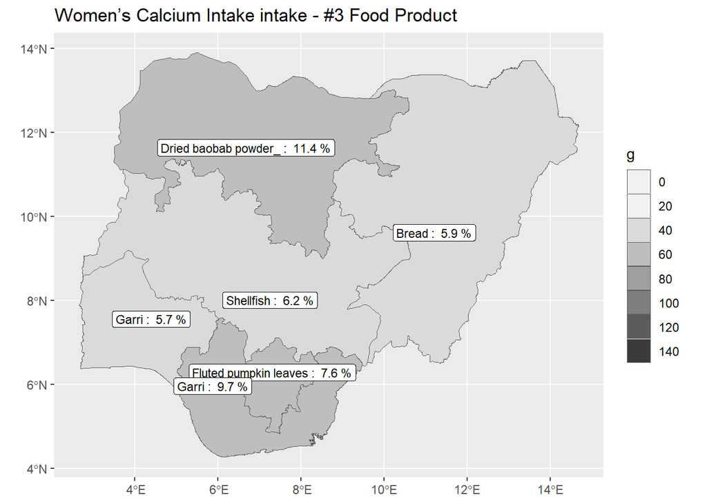

```r
ggplot(vect_gpz_geo_NFCMS_A19) +
  geom_spatvector(aes(fill = SN3_g)) +
  geom_spatvector_label(
    aes(label = paste(SN3_Name, ": ", SN3_pc, "%")),
    position = position_jitter(width = 0.1, height = 1.2, seed = 3),
    size = 3
  ) +
  scale_fill_stepsn(
    n.breaks = 10,
    limits = c(0, 150),
    colours = hcl.colors(palette = "Grays", 10, rev = T),
    guide = "legend",
    na.value = "pink",
    labels = scales::comma
  ) +
  labs(
    title = "Women's Calcium Intake intake - #3 Food Product",
    fill = "g"
  ) +
  theme(
    plot.title = element_markdown(),
    legend.title = element_markdown(),
    axis.title = element_blank()
  )
```

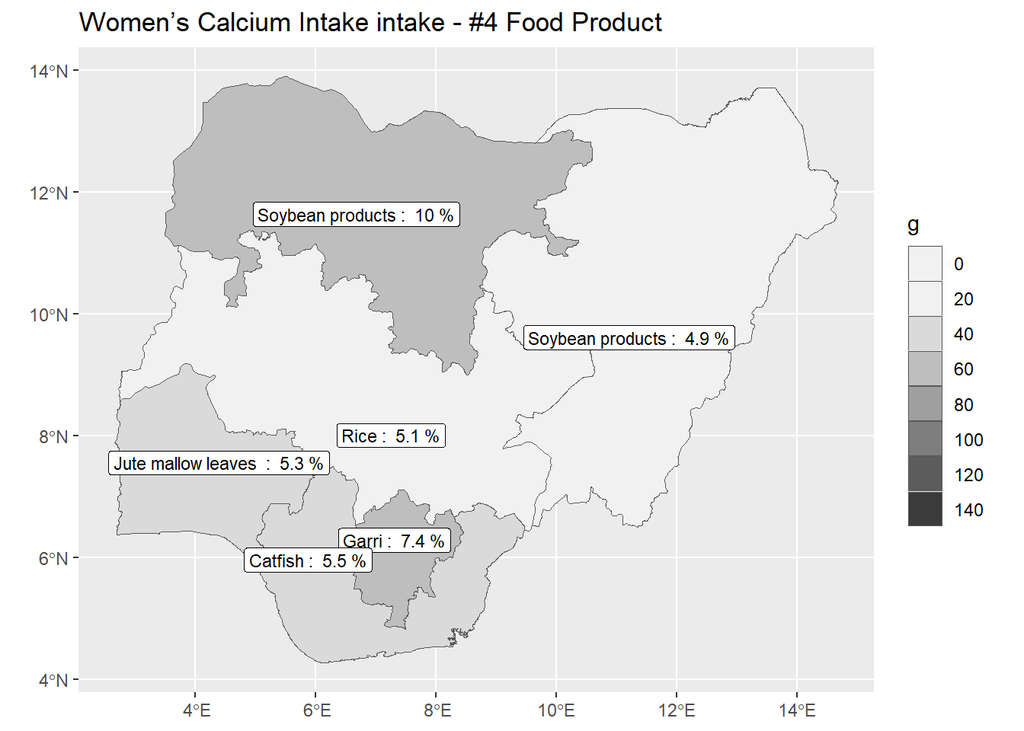

```r
ggplot(vect_gpz_geo_NFCMS_A19) +
  geom_spatvector(aes(fill = SN4_g)) +
  geom_spatvector_label(
    aes(label = paste(SN4_Name, ": ", SN4_pc, "%")),
    position = position_jitter(width = 0.1, height = 1.2, seed = 3),
    size = 3
  ) +
  scale_fill_stepsn(
    n.breaks = 10,
    limits = c(0, 150),
    colours = hcl.colors(palette = "Grays", 10, rev = T),
    guide = "legend",
    na.value = "pink",
    labels = scales::comma
  ) +
  labs(
    title = "Women's Calcium Intake intake - #4 Food Product",
    fill = "g"
  ) +
  theme(
    plot.title = element_markdown(),
    legend.title = element_markdown(),
    axis.title = element_blank()
  )
```

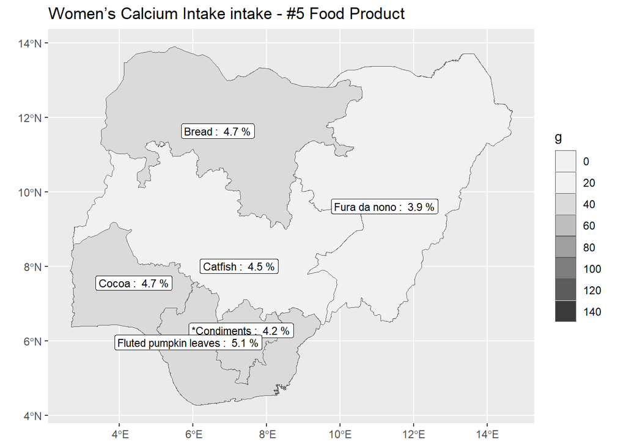

```r
ggplot(vect_gpz_geo_NFCMS_A19) +
  geom_spatvector(aes(fill = SN5_g)) +
  geom_spatvector_label(
    aes(label = paste(SN5_Name, ": ", SN5_pc, "%")),
    position = position_jitter(width = 0.1, height = 1.2, seed = 3),
    size = 3
  ) +
  scale_fill_stepsn(
    n.breaks = 10,
    limits = c(0, 150),
    colours = hcl.colors(palette = "Grays", 10, rev = T),
    guide = "legend",
    na.value = "pink",
    labels = scales::comma
  ) +
  labs(
    title = "Women's Calcium Intake intake - #5 Food Product",
    fill = "g"
  ) +
  theme(
    plot.title = element_markdown(),
    legend.title = element_markdown(),
    axis.title = element_blank()
  )
```

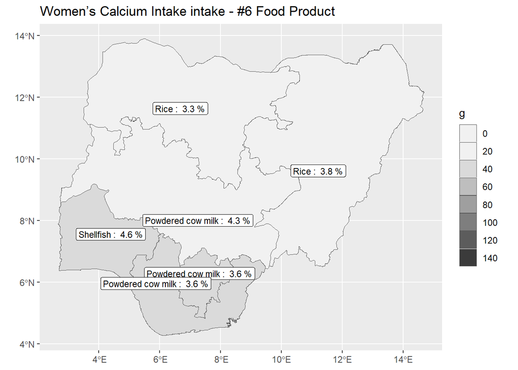

```r
ggplot(vect_gpz_geo_NFCMS_A19) +
  geom_spatvector(aes(fill = SN6_g)) +
  geom_spatvector_label(
    aes(label = paste(SN6_Name, ": ", SN6_pc, "%")),
    position = position_jitter(width = 0.1, height = 1.2, seed = 3),
    size = 3
  ) +
  scale_fill_stepsn(
    n.breaks = 10,
    limits = c(0, 150),
    colours = hcl.colors(palette = "Grays", 10, rev = T),
    guide = "legend",
    na.value = "pink",
    labels = scales::comma
  ) +
  labs(
    title = "Women's Calcium Intake intake - #6 Food Product",
    fill = "g"
  ) +
  theme(
    plot.title = element_markdown(),
    legend.title = element_markdown(),
    axis.title = element_blank()
  )
```

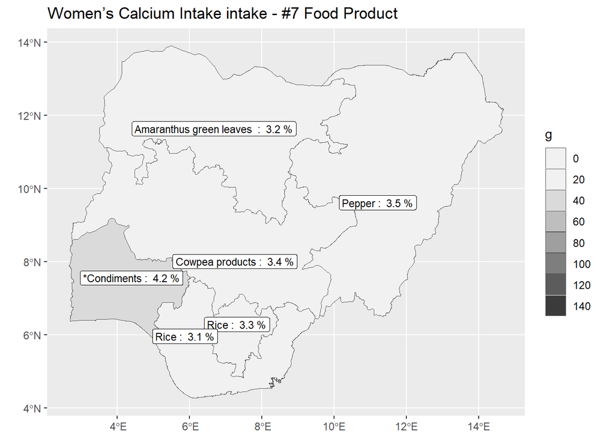

```r
ggplot(vect_gpz_geo_NFCMS_A19) +
  geom_spatvector(aes(fill = SN7_g)) +
  geom_spatvector_label(
    aes(label = paste(SN7_Name, ": ", SN7_pc, "%")),
    position = position_jitter(width = 0.1, height = 1.2, seed = 3),
    size = 3
  ) +
  scale_fill_stepsn(
    n.breaks = 10,
    limits = c(0, 150),
    colours = hcl.colors(palette = "Grays", 10, rev = T),
    guide = "legend",
    na.value = "pink",
    labels = scales::comma
  ) +
  labs(
    title = "Women's Calcium Intake intake - #7 Food Product",
    fill = "g"
  ) +
  theme(
    plot.title = element_markdown(),
    legend.title = element_markdown(),
    axis.title = element_blank()
  )
```

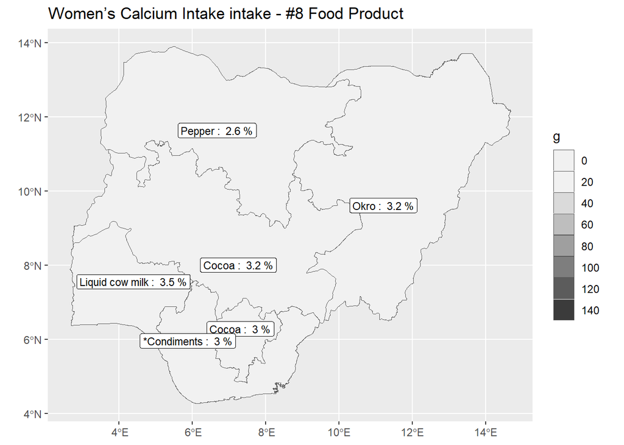

```r
ggplot(vect_gpz_geo_NFCMS_A19) +
  geom_spatvector(aes(fill = SN8_g)) +
  geom_spatvector_label(
    aes(label = paste(SN8_Name, ": ", SN8_pc, "%")),
    position = position_jitter(width = 0.1, height = 1.2, seed = 3),
    size = 3
  ) +
  scale_fill_stepsn(
    n.breaks = 10,
    limits = c(0, 150),
    colours = hcl.colors(palette = "Grays", 10, rev = T),
    guide = "legend",
    na.value = "pink",
    labels = scales::comma
  ) +
  labs(
    title = "Women's Calcium Intake intake - #8 Food Product",
    fill = "g"
  ) +
  theme(
    plot.title = element_markdown(),
    legend.title = element_markdown(),
    axis.title = element_blank()
  )
```

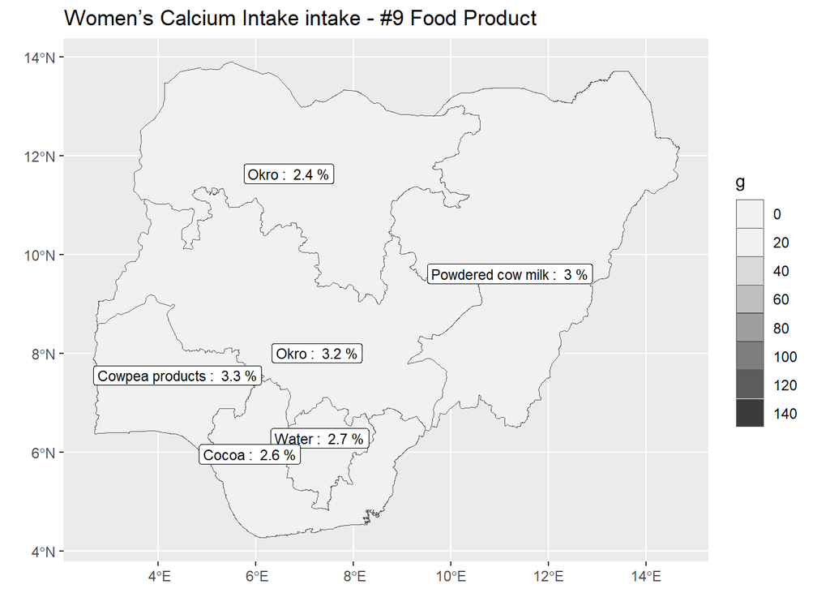

```r
ggplot(vect_gpz_geo_NFCMS_A19) +
  geom_spatvector(aes(fill = SN9_g)) +
  geom_spatvector_label(
    aes(label = paste(SN9_Name, ": ", SN9_pc, "%")),
    position = position_jitter(width = 0.1, height = 1.2, seed = 3),
    size = 3
  ) +
  scale_fill_stepsn(
    n.breaks = 10,
    limits = c(0, 150),
    colours = hcl.colors(palette = "Grays", 10, rev = T),
    guide = "legend",
    na.value = "pink",
    labels = scales::comma
  ) +
  labs(
    title = "Women's Calcium Intake intake - #9 Food Product",
    fill = "g"
  ) +
  theme(
    plot.title = element_markdown(),
    legend.title = element_markdown(),
    axis.title = element_blank()
  )
```

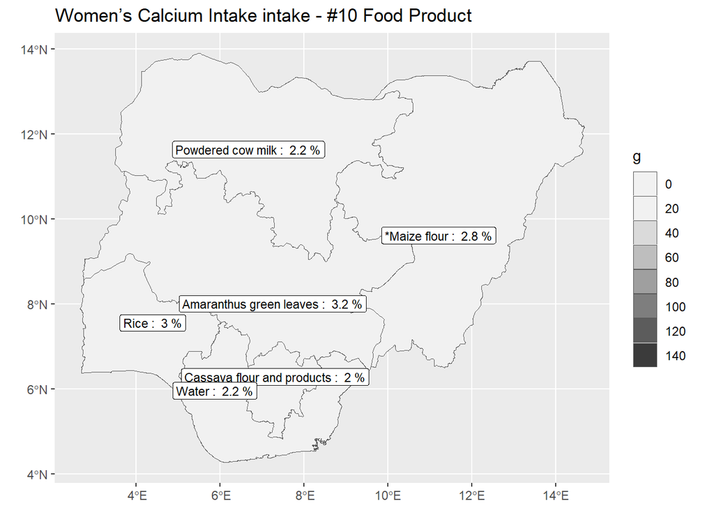

```r
ggplot(vect_gpz_geo_NFCMS_A19) +
  geom_spatvector(aes(fill = SN10_g)) +
  geom_spatvector_label(
    aes(label = paste(SN10_Name, ": ", SN10_pc, "%")),
    position = position_jitter(width = 0.1, height = 1.2, seed = 3),
    size = 3
  ) +
  scale_fill_stepsn(
    n.breaks = 10,
    limits = c(0, 150),
    colours = hcl.colors(palette = "Grays", 10, rev = T),
    guide = "legend",
    na.value = "pink",
    labels = scales::comma
  ) +
  labs(
    title = "Women's Calcium Intake intake - #10 Food Product",
    fill = "g"
  ) +
  theme(
    plot.title = element_markdown(),
    legend.title = element_markdown(),
    axis.title = element_blank()
  )
```

## Calcium intake (NFCMS, 2021)

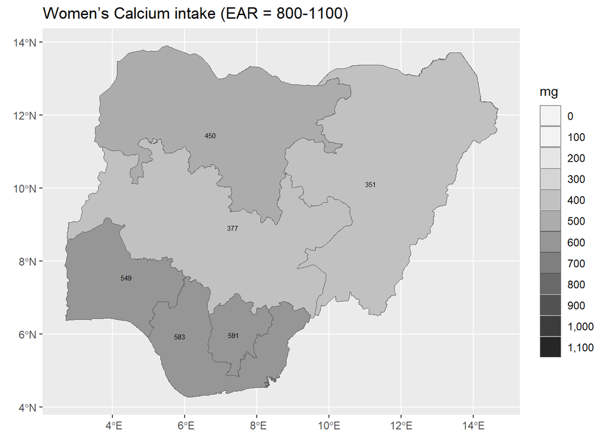

```r
ggplot(vect_gpz_geo_NFCMS) +
  geom_spatvector(aes(fill = CALC_IN_W_67)) +
  geom_spatvector_text(aes(label = CALC_IN_W_67), size = 2) +
  scale_fill_stepsn(
    n.breaks = 10,
    limits = c(0, 1100),
    colours = hcl.colors(palette = "Grays", 10, rev = T),
    guide = "legend",
    na.value = "pink",
    labels = scales::comma
  ) +
  labs(title = "Women's Calcium intake (EAR = 800-1100) ", fill = "mg") +
  theme(
    plot.title = element_markdown(),
    legend.title = element_markdown(),
    axis.title = element_blank()
  )
```

Calcium intake is highest in the southern zones, and also in North West (where dairy products are consumed).

The average intake in all zones is below the recommended intake for non-pregnant women.

## Total Iron intake

The NFCMS provides a list of the 10 food products that contribute most to Iron intake for each zone. These data provide context to the macro-nutrient intake for each zone, and provide insights into the food basket composition for each zone.

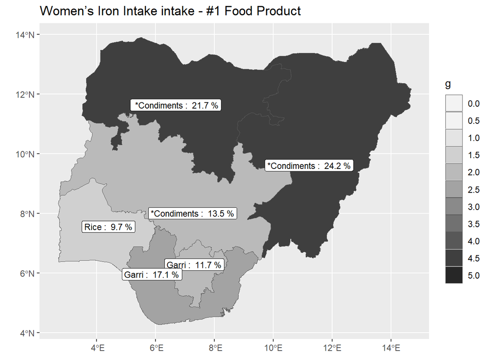

```r
ggplot(vect_gpz_geo_NFCMS_A21) +
  geom_spatvector(aes(fill = SN1_g)) +
  geom_spatvector_label(
    aes(label = paste(SN1_Name, ": ", SN1_pc, "%")),
    position = position_jitter(width = 0.1, height = 1.2, seed = 3),
    size = 3
  ) +
  scale_fill_stepsn(
    n.breaks = 10,
    limits = c(0, 5),
    colours = hcl.colors(palette = "Grays", 10, rev = T),
    guide = "legend",
    na.value = "pink",
    labels = scales::comma
  ) +
  labs(
    title = "Women's Iron Intake intake - #1 Food Product",
    fill = "g"
  ) +
  theme(
    plot.title = element_markdown(),
    legend.title = element_markdown(),
    axis.title = element_blank()
  )
```

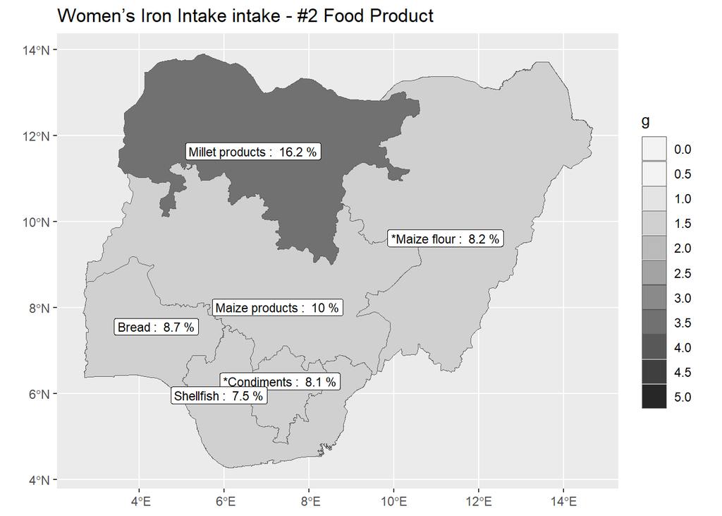

```r
ggplot(vect_gpz_geo_NFCMS_A21) +
  geom_spatvector(aes(fill = SN2_g)) +
  geom_spatvector_label(
    aes(label = paste(SN2_Name, ": ", SN2_pc, "%")),
    position = position_jitter(width = 0.1, height = 1.2, seed = 3),
    size = 3
  ) +
  scale_fill_stepsn(
    n.breaks = 10,
    limits = c(0, 5),
    colours = hcl.colors(palette = "Grays", 10, rev = T),
    guide = "legend",
    na.value = "pink",
    labels = scales::comma
  ) +
  labs(
    title = "Women's Iron Intake intake - #2 Food Product",
    fill = "g"
  ) +
  theme(
    plot.title = element_markdown(),
    legend.title = element_markdown(),
    axis.title = element_blank()
  )
```

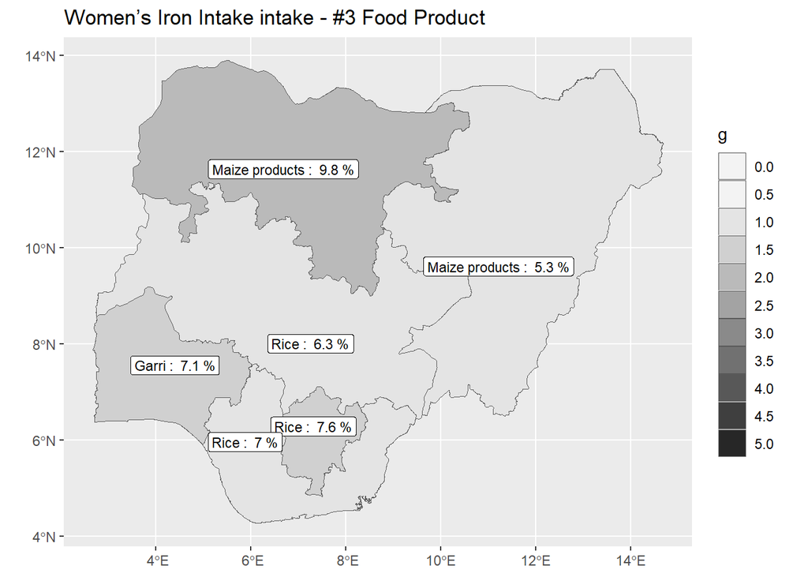

```r
ggplot(vect_gpz_geo_NFCMS_A21) +
  geom_spatvector(aes(fill = SN3_g)) +
  geom_spatvector_label(
    aes(label = paste(SN3_Name, ": ", SN3_pc, "%")),
    position = position_jitter(width = 0.1, height = 1.2, seed = 3),
    size = 3
  ) +
  scale_fill_stepsn(
    n.breaks = 10,
    limits = c(0, 5),
    colours = hcl.colors(palette = "Grays", 10, rev = T),
    guide = "legend",
    na.value = "pink",
    labels = scales::comma
  ) +
  labs(
    title = "Women's Iron Intake intake - #3 Food Product",
    fill = "g"
  ) +
  theme(
    plot.title = element_markdown(),
    legend.title = element_markdown(),
    axis.title = element_blank()
  )
```

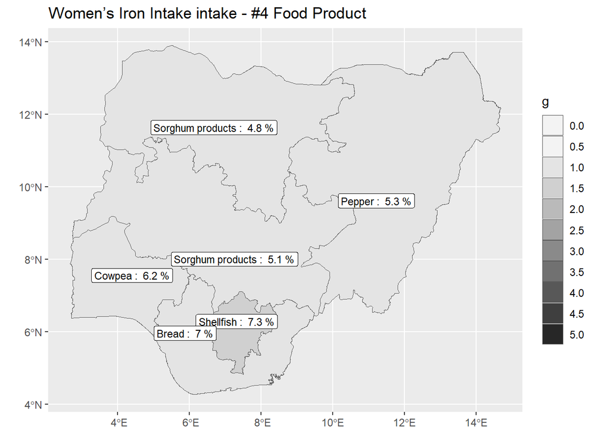

```r
ggplot(vect_gpz_geo_NFCMS_A21) +
  geom_spatvector(aes(fill = SN4_g)) +
  geom_spatvector_label(
    aes(label = paste(SN4_Name, ": ", SN4_pc, "%")),
    position = position_jitter(width = 0.1, height = 1.2, seed = 3),
    size = 3
  ) +
  scale_fill_stepsn(
    n.breaks = 10,
    limits = c(0, 5),
    colours = hcl.colors(palette = "Grays", 10, rev = T),
    guide = "legend",
    na.value = "pink",
    labels = scales::comma
  ) +
  labs(
    title = "Women's Iron Intake intake - #4 Food Product",
    fill = "g"
  ) +
  theme(
    plot.title = element_markdown(),
    legend.title = element_markdown(),
    axis.title = element_blank()
  )
```

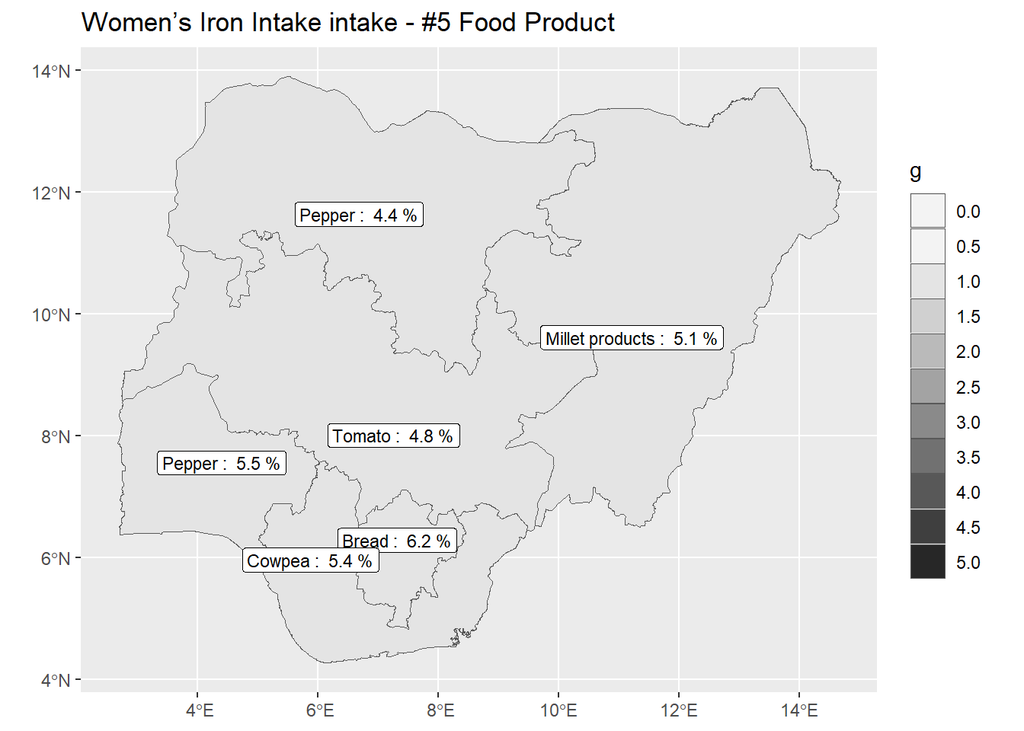

```r
ggplot(vect_gpz_geo_NFCMS_A21) +
  geom_spatvector(aes(fill = SN5_g)) +
  geom_spatvector_label(
    aes(label = paste(SN5_Name, ": ", SN5_pc, "%")),
    position = position_jitter(width = 0.1, height = 1.2, seed = 3),
    size = 3
  ) +
  scale_fill_stepsn(
    n.breaks = 10,
    limits = c(0, 5),
    colours = hcl.colors(palette = "Grays", 10, rev = T),
    guide = "legend",
    na.value = "pink",
    labels = scales::comma
  ) +
  labs(
    title = "Women's Iron Intake intake - #5 Food Product",
    fill = "g"
  ) +
  theme(
    plot.title = element_markdown(),
    legend.title = element_markdown(),
    axis.title = element_blank()
  )
```

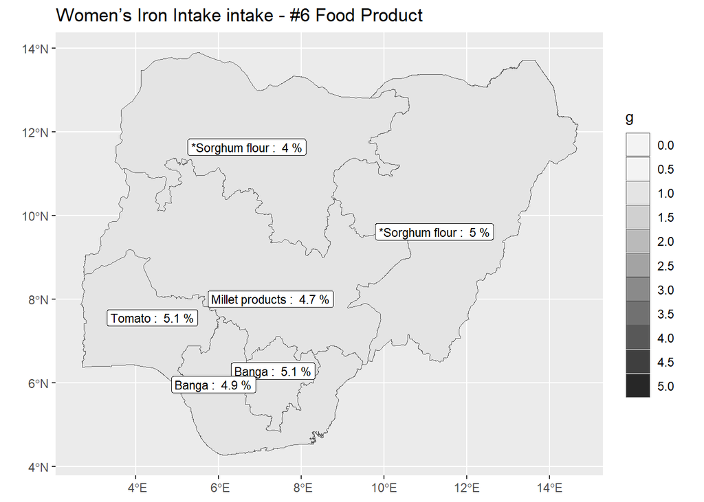

```r
ggplot(vect_gpz_geo_NFCMS_A21) +
  geom_spatvector(aes(fill = SN6_g)) +
  geom_spatvector_label(
    aes(label = paste(SN6_Name, ": ", SN6_pc, "%")),
    position = position_jitter(width = 0.1, height = 1.2, seed = 3),
    size = 3
  ) +
  scale_fill_stepsn(
    n.breaks = 10,
    limits = c(0, 5),
    colours = hcl.colors(palette = "Grays", 10, rev = T),
    guide = "legend",
    na.value = "pink",
    labels = scales::comma
  ) +
  labs(
    title = "Women's Iron Intake intake - #6 Food Product",
    fill = "g"
  ) +
  theme(
    plot.title = element_markdown(),
    legend.title = element_markdown(),
    axis.title = element_blank()
  )
```

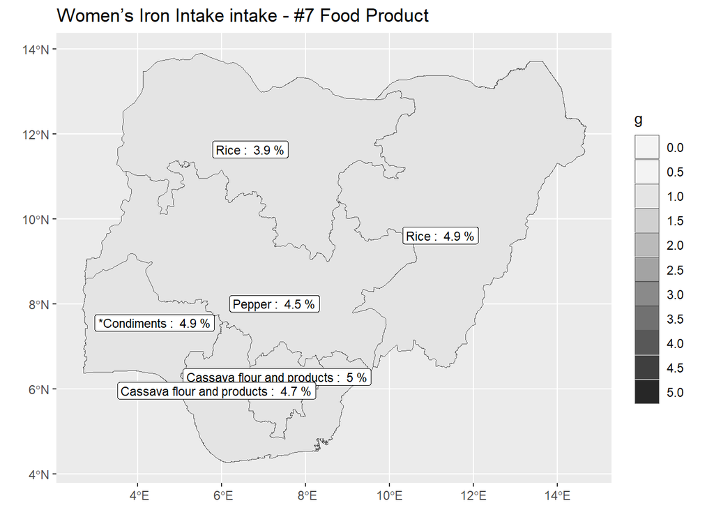

```r
ggplot(vect_gpz_geo_NFCMS_A21) +
  geom_spatvector(aes(fill = SN7_g)) +
  geom_spatvector_label(
    aes(label = paste(SN7_Name, ": ", SN7_pc, "%")),
    position = position_jitter(width = 0.1, height = 1.2, seed = 3),
    size = 3
  ) +
  scale_fill_stepsn(
    n.breaks = 10,
    limits = c(0, 5),
    colours = hcl.colors(palette = "Grays", 10, rev = T),
    guide = "legend",
    na.value = "pink",
    labels = scales::comma
  ) +
  labs(
    title = "Women's Iron Intake intake - #7 Food Product",
    fill = "g"
  ) +
  theme(
    plot.title = element_markdown(),
    legend.title = element_markdown(),
    axis.title = element_blank()
  )
```

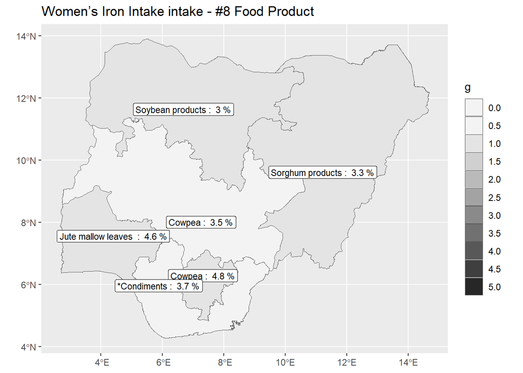

```r
ggplot(vect_gpz_geo_NFCMS_A21) +
  geom_spatvector(aes(fill = SN8_g)) +
  geom_spatvector_label(
    aes(label = paste(SN8_Name, ": ", SN8_pc, "%")),
    position = position_jitter(width = 0.1, height = 1.2, seed = 3),
    size = 3
  ) +
  scale_fill_stepsn(
    n.breaks = 10,
    limits = c(0, 5),
    colours = hcl.colors(palette = "Grays", 10, rev = T),
    guide = "legend",
    na.value = "pink",
    labels = scales::comma
  ) +
  labs(
    title = "Women's Iron Intake intake - #8 Food Product",
    fill = "g"
  ) +
  theme(
    plot.title = element_markdown(),
    legend.title = element_markdown(),
    axis.title = element_blank()
  )
```

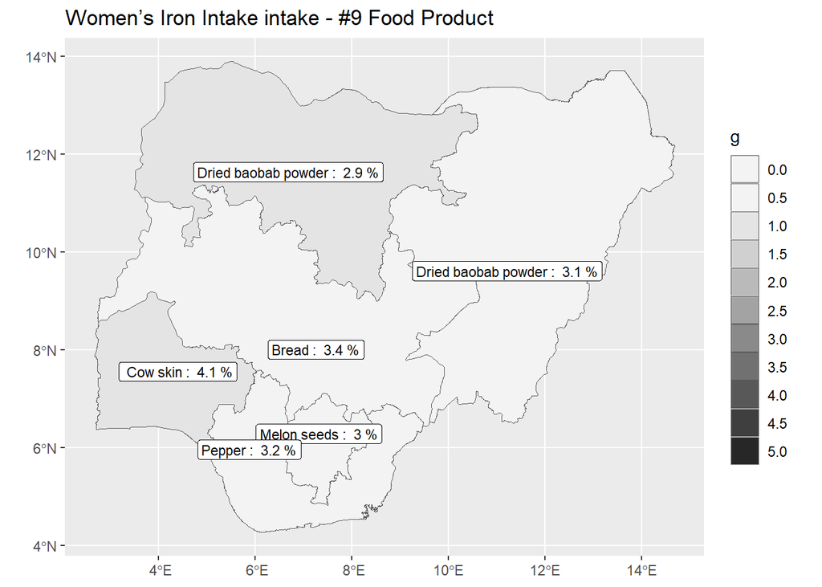

```r
ggplot(vect_gpz_geo_NFCMS_A21) +
  geom_spatvector(aes(fill = SN9_g)) +
  geom_spatvector_label(
    aes(label = paste(SN9_Name, ": ", SN9_pc, "%")),
    position = position_jitter(width = 0.1, height = 1.2, seed = 3),
    size = 3
  ) +
  scale_fill_stepsn(
    n.breaks = 10,
    limits = c(0, 5),
    colours = hcl.colors(palette = "Grays", 10, rev = T),
    guide = "legend",
    na.value = "pink",
    labels = scales::comma
  ) +
  labs(
    title = "Women's Iron Intake intake - #9 Food Product",
    fill = "g"
  ) +
  theme(
    plot.title = element_markdown(),
    legend.title = element_markdown(),
    axis.title = element_blank()
  )
```

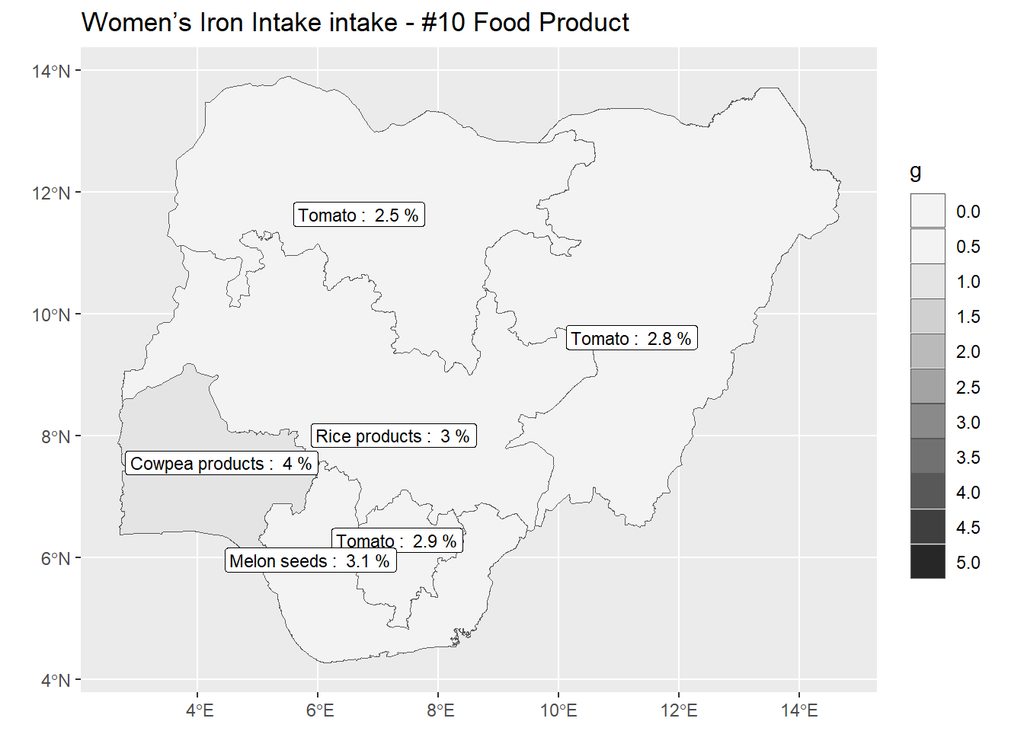

```r
ggplot(vect_gpz_geo_NFCMS_A21) +
  geom_spatvector(aes(fill = SN10_g)) +
  geom_spatvector_label(
    aes(label = paste(SN10_Name, ": ", SN10_pc, "%")),
    position = position_jitter(width = 0.1, height = 1.2, seed = 3),
    size = 3
  ) +
  scale_fill_stepsn(
    n.breaks = 10,
    limits = c(0, 5),
    colours = hcl.colors(palette = "Grays", 10, rev = T),
    guide = "legend",
    na.value = "pink",
    labels = scales::comma
  ) +
  labs(
    title = "Women's Iron Intake intake - #10 Food Product",
    fill = "g"
  ) +
  theme(
    plot.title = element_markdown(),
    legend.title = element_markdown(),
    axis.title = element_blank()
  )
```

## Iron intake (NFCMS, 2021)

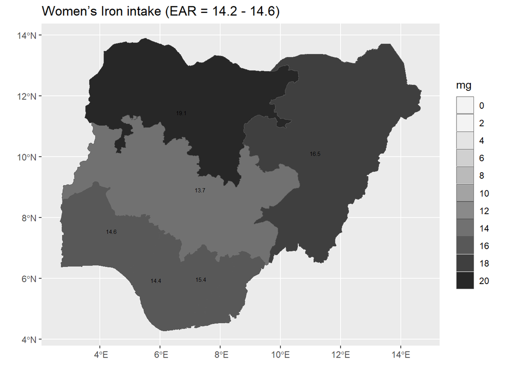

```r
ggplot(vect_gpz_geo_NFCMS) +
  geom_spatvector(aes(fill = IRON_IN_W_71)) +
  geom_spatvector_text(aes(label = IRON_IN_W_71), size = 2) +
  scale_fill_stepsn(
    n.breaks = 10,
    limits = c(0, 20),
    colours = hcl.colors(palette = "Grays", 10, rev = T),
    guide = "legend",
    na.value = "pink",
    labels = scales::comma
  ) +
  labs(title = "Women's Iron intake (EAR = 14.2 - 14.6)", fill = "mg") +
  theme(
    plot.title = element_markdown(),
    legend.title = element_markdown(),
    axis.title = element_blank()
  )
```

Iron intake is highest in North West and North East zones.

The average intake is above the recommended intake for non-pregnant women in three zones: North East, North West and South East, within the range for South South and South West, and below the recommended intake in North Central.

## Total Zinc intake

The NFCMS provides a list of the 10 food products that contribute most to Zinc intake for each zone. These data provide context to the macro-nutrient intake for each zone, and provide insights into the food basket composition for each zone.

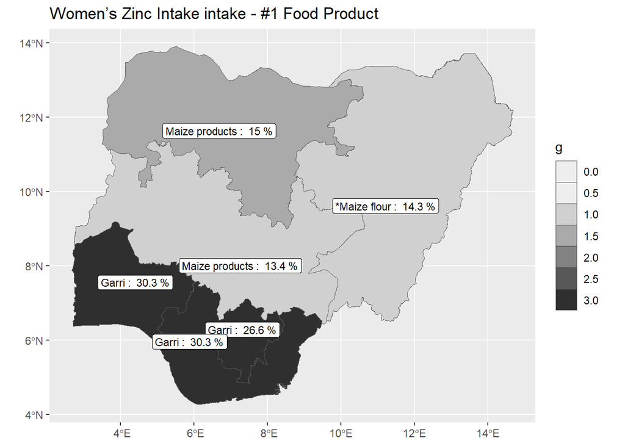

```r
ggplot(vect_gpz_geo_NFCMS_A23) +
  geom_spatvector(aes(fill = SN1_g)) +
  geom_spatvector_label(
    aes(label = paste(SN1_Name, ": ", SN1_pc, "%")),
    position = position_jitter(width = 0.1, height = 1.2, seed = 3),
    size = 3
  ) +
  scale_fill_stepsn(
    n.breaks = 10,
    limits = c(0, 3),
    colours = hcl.colors(palette = "Grays", 10, rev = T),
    guide = "legend",
    na.value = "pink",
    labels = scales::comma
  ) +
  labs(
    title = "Women's Zinc Intake intake - #1 Food Product",
    fill = "g"
  ) +
  theme(
    plot.title = element_markdown(),
    legend.title = element_markdown(),
    axis.title = element_blank()
  )
```

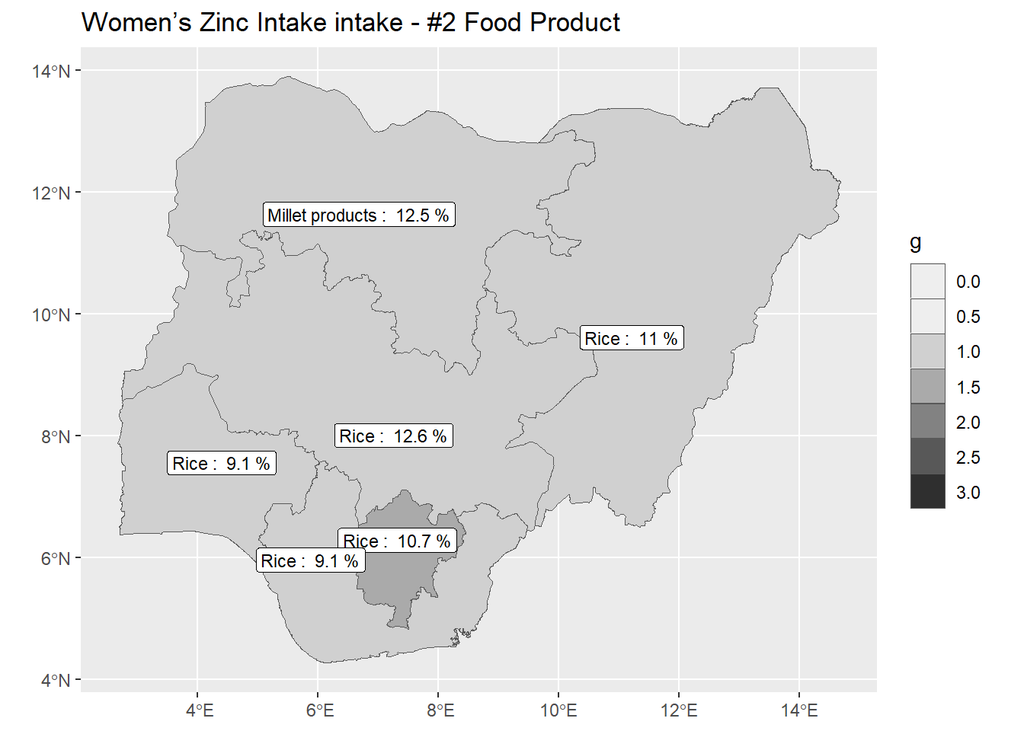

```r
ggplot(vect_gpz_geo_NFCMS_A23) +
  geom_spatvector(aes(fill = SN2_g)) +
  geom_spatvector_label(
    aes(label = paste(SN2_Name, ": ", SN2_pc, "%")),
    position = position_jitter(width = 0.1, height = 1.2, seed = 3),
    size = 3
  ) +
  scale_fill_stepsn(
    n.breaks = 10,
    limits = c(0, 3),
    colours = hcl.colors(palette = "Grays", 10, rev = T),
    guide = "legend",
    na.value = "pink",
    labels = scales::comma
  ) +
  labs(
    title = "Women's Zinc Intake intake - #2 Food Product",
    fill = "g"
  ) +
  theme(
    plot.title = element_markdown(),
    legend.title = element_markdown(),
    axis.title = element_blank()
  )
```

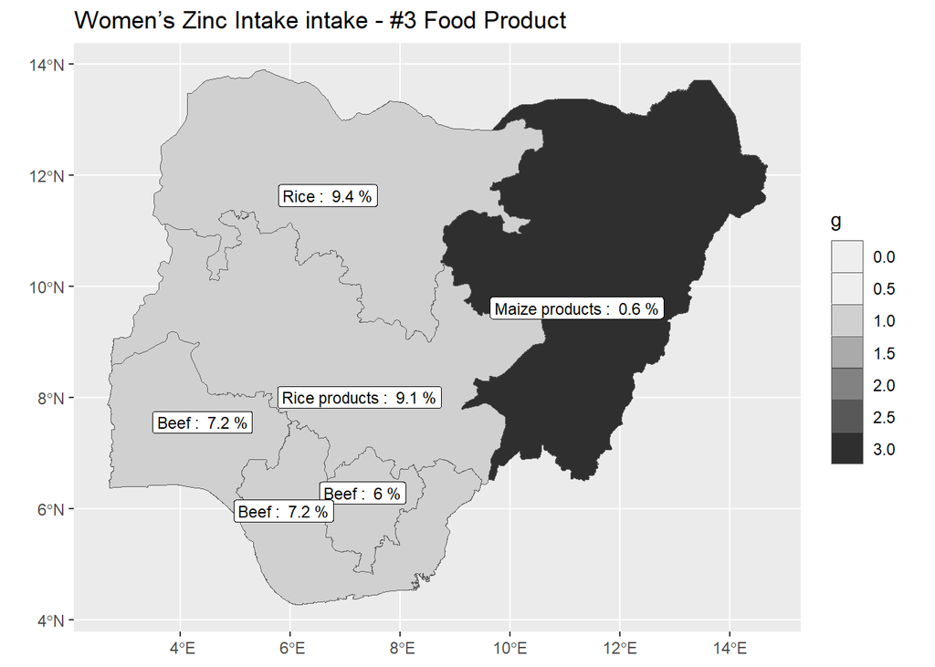

```r
ggplot(vect_gpz_geo_NFCMS_A23) +
  geom_spatvector(aes(fill = SN3_g)) +
  geom_spatvector_label(
    aes(label = paste(SN3_Name, ": ", SN3_pc, "%")),
    position = position_jitter(width = 0.1, height = 1.2, seed = 3),
    size = 3
  ) +
  scale_fill_stepsn(
    n.breaks = 10,
    limits = c(0, 3),
    colours = hcl.colors(palette = "Grays", 10, rev = T),
    guide = "legend",
    na.value = "pink",
    labels = scales::comma
  ) +
  labs(
    title = "Women's Zinc Intake intake - #3 Food Product",
    fill = "g"
  ) +
  theme(
    plot.title = element_markdown(),
    legend.title = element_markdown(),
    axis.title = element_blank()
  )
```

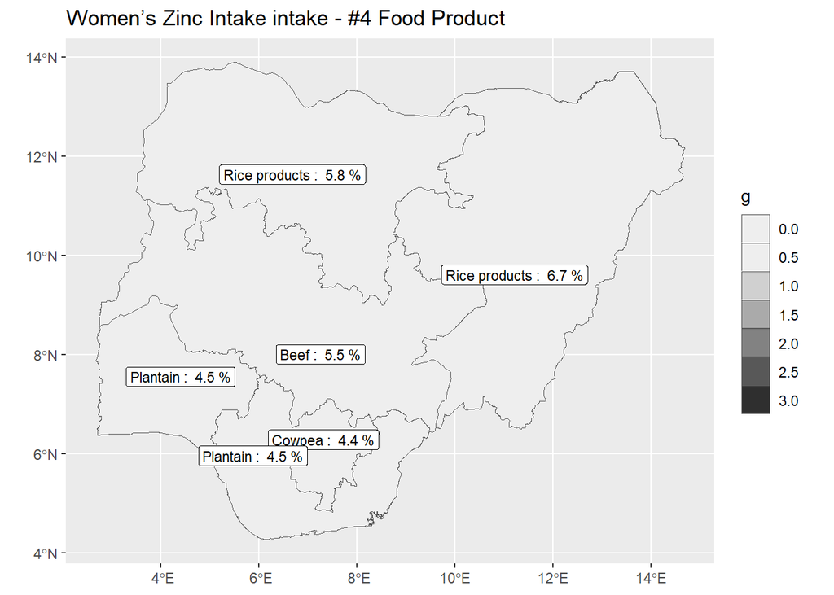

```r
ggplot(vect_gpz_geo_NFCMS_A23) +
  geom_spatvector(aes(fill = SN4_g)) +
  geom_spatvector_label(
    aes(label = paste(SN4_Name, ": ", SN4_pc, "%")),
    position = position_jitter(width = 0.1, height = 1.2, seed = 3),
    size = 3
  ) +
  scale_fill_stepsn(
    n.breaks = 10,
    limits = c(0, 3),
    colours = hcl.colors(palette = "Grays", 10, rev = T),
    guide = "legend",
    na.value = "pink",
    labels = scales::comma
  ) +
  labs(
    title = "Women's Zinc Intake intake - #4 Food Product",
    fill = "g"
  ) +
  theme(
    plot.title = element_markdown(),
    legend.title = element_markdown(),
    axis.title = element_blank()
  )
```

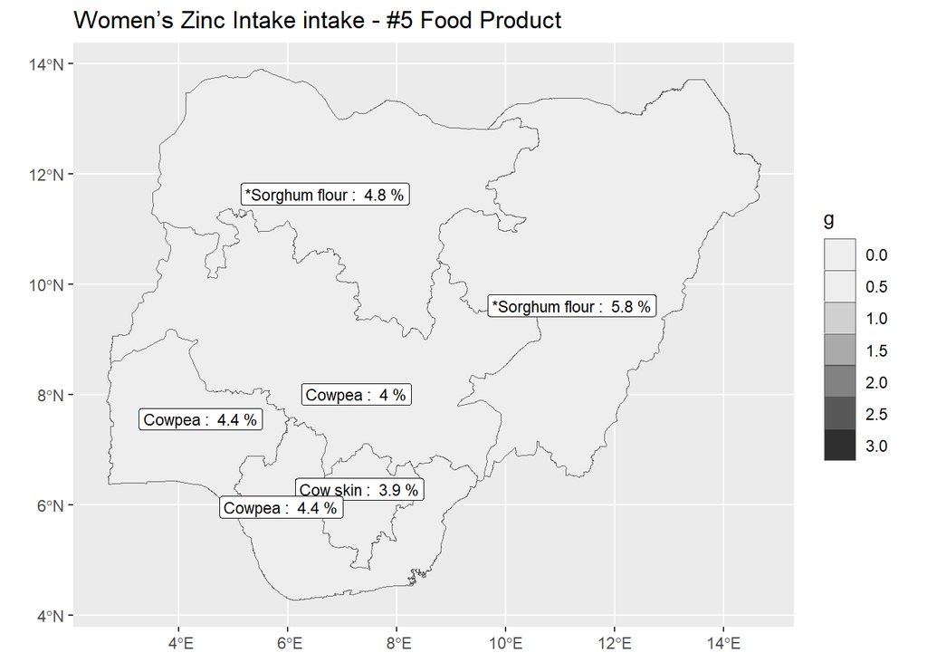

```r
ggplot(vect_gpz_geo_NFCMS_A23) +
  geom_spatvector(aes(fill = SN5_g)) +
  geom_spatvector_label(
    aes(label = paste(SN5_Name, ": ", SN5_pc, "%")),
    position = position_jitter(width = 0.1, height = 1.2, seed = 3),
    size = 3
  ) +
  scale_fill_stepsn(
    n.breaks = 10,
    limits = c(0, 3),
    colours = hcl.colors(palette = "Grays", 10, rev = T),
    guide = "legend",
    na.value = "pink",
    labels = scales::comma
  ) +
  labs(
    title = "Women's Zinc Intake intake - #5 Food Product",
    fill = "g"
  ) +
  theme(
    plot.title = element_markdown(),
    legend.title = element_markdown(),
    axis.title = element_blank()
  )
```

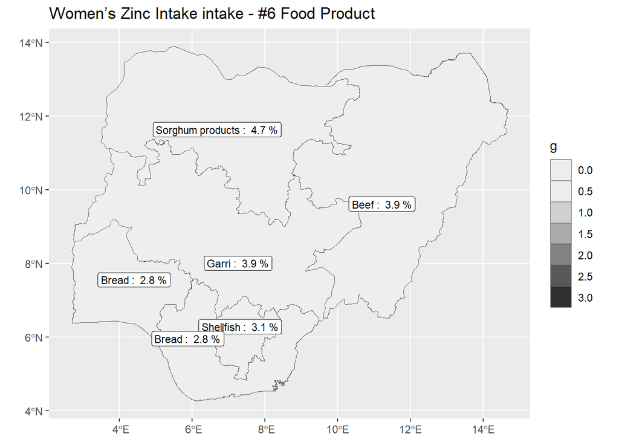

```r
ggplot(vect_gpz_geo_NFCMS_A23) +
  geom_spatvector(aes(fill = SN6_g)) +
  geom_spatvector_label(
    aes(label = paste(SN6_Name, ": ", SN6_pc, "%")),
    position = position_jitter(width = 0.1, height = 1.2, seed = 3),
    size = 3
  ) +
  scale_fill_stepsn(
    n.breaks = 10,
    limits = c(0, 3),
    colours = hcl.colors(palette = "Grays", 10, rev = T),
    guide = "legend",
    na.value = "pink",
    labels = scales::comma
  ) +
  labs(
    title = "Women's Zinc Intake intake - #6 Food Product",
    fill = "g"
  ) +
  theme(
    plot.title = element_markdown(),
    legend.title = element_markdown(),
    axis.title = element_blank()
  )
```

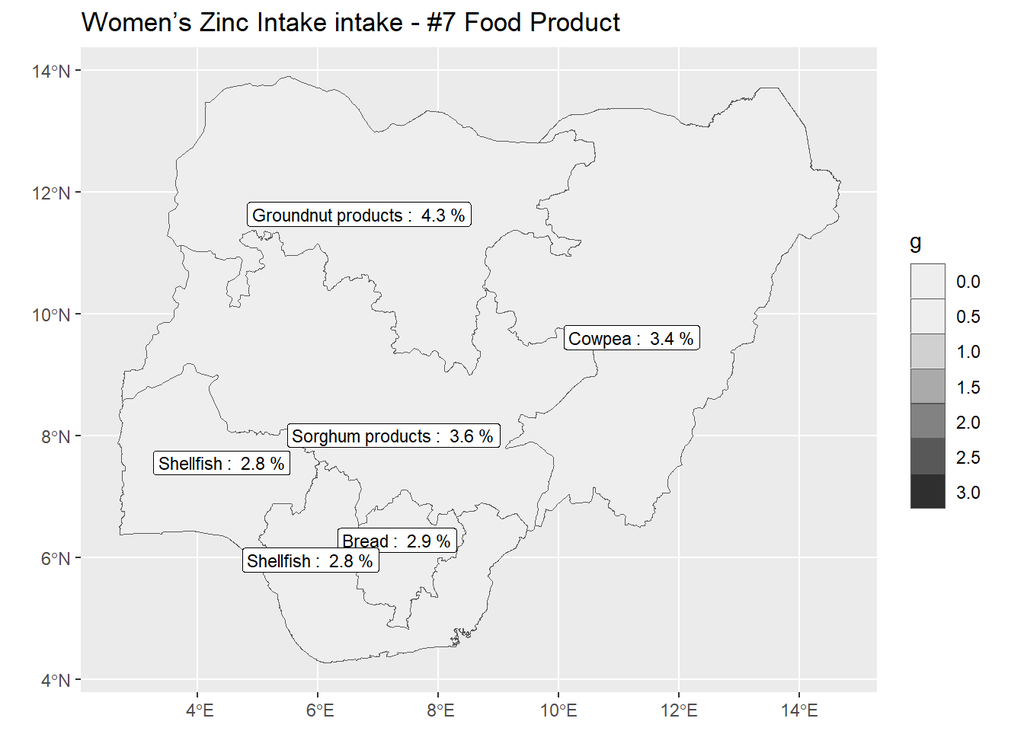

```r
ggplot(vect_gpz_geo_NFCMS_A23) +
  geom_spatvector(aes(fill = SN7_g)) +
  geom_spatvector_label(
    aes(label = paste(SN7_Name, ": ", SN7_pc, "%")),
    position = position_jitter(width = 0.1, height = 1.2, seed = 3),
    size = 3
  ) +
  scale_fill_stepsn(
    n.breaks = 10,
    limits = c(0, 3),
    colours = hcl.colors(palette = "Grays", 10, rev = T),
    guide = "legend",
    na.value = "pink",
    labels = scales::comma
  ) +
  labs(
    title = "Women's Zinc Intake intake - #7 Food Product",
    fill = "g"
  ) +
  theme(
    plot.title = element_markdown(),
    legend.title = element_markdown(),
    axis.title = element_blank()
  )
```

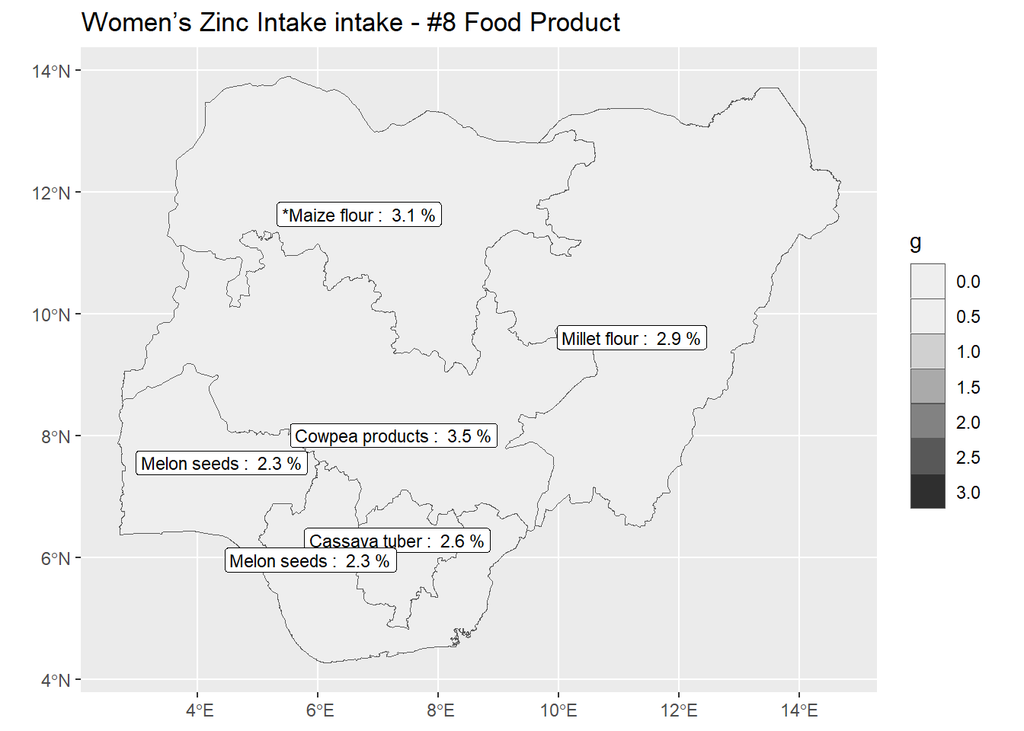

```r
ggplot(vect_gpz_geo_NFCMS_A23) +
  geom_spatvector(aes(fill = SN8_g)) +
  geom_spatvector_label(
    aes(label = paste(SN8_Name, ": ", SN8_pc, "%")),
    position = position_jitter(width = 0.1, height = 1.2, seed = 3),
    size = 3
  ) +
  scale_fill_stepsn(
    n.breaks = 10,
    limits = c(0, 3),
    colours = hcl.colors(palette = "Grays", 10, rev = T),
    guide = "legend",
    na.value = "pink",
    labels = scales::comma
  ) +
  labs(
    title = "Women's Zinc Intake intake - #8 Food Product",
    fill = "g"
  ) +
  theme(
    plot.title = element_markdown(),
    legend.title = element_markdown(),
    axis.title = element_blank()
  )
```

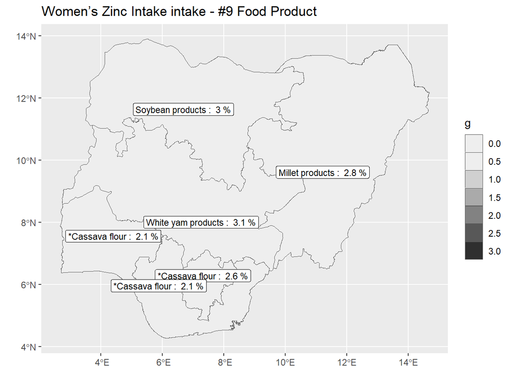

```r
ggplot(vect_gpz_geo_NFCMS_A23) +
  geom_spatvector(aes(fill = SN9_g)) +
  geom_spatvector_label(
    aes(label = paste(SN9_Name, ": ", SN9_pc, "%")),
    position = position_jitter(width = 0.1, height = 1.2, seed = 3),
    size = 3
  ) +
  scale_fill_stepsn(
    n.breaks = 10,
    limits = c(0, 3),
    colours = hcl.colors(palette = "Grays", 10, rev = T),
    guide = "legend",
    na.value = "pink",
    labels = scales::comma
  ) +
  labs(
    title = "Women's Zinc Intake intake - #9 Food Product",
    fill = "g"
  ) +
  theme(
    plot.title = element_markdown(),
    legend.title = element_markdown(),
    axis.title = element_blank()
  )
```

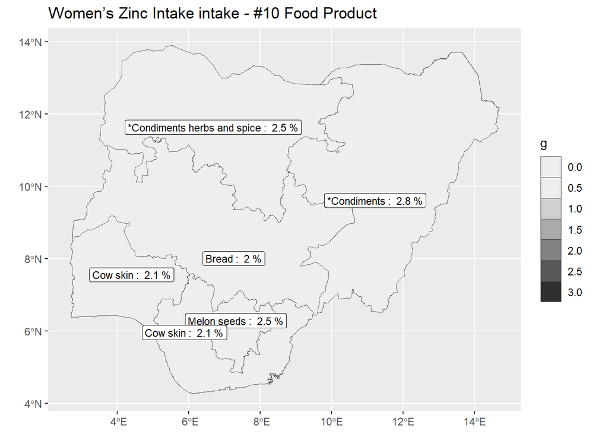

```r
ggplot(vect_gpz_geo_NFCMS_A23) +
  geom_spatvector(aes(fill = SN10_g)) +
  geom_spatvector_label(
    aes(label = paste(SN10_Name, ": ", SN10_pc, "%")),
    position = position_jitter(width = 0.1, height = 1.2, seed = 3),
    size = 3
  ) +
  scale_fill_stepsn(
    n.breaks = 10,
    limits = c(0, 3),
    colours = hcl.colors(palette = "Grays", 10, rev = T),
    guide = "legend",
    na.value = "pink",
    labels = scales::comma
  ) +
  labs(
    title = "Women's Zinc Intake intake - #10 Food Product",
    fill = "g"
  ) +
  theme(
    plot.title = element_markdown(),
    legend.title = element_markdown(),
    axis.title = element_blank()
  )
```

## Zinc intake (NFCMS, 2021)

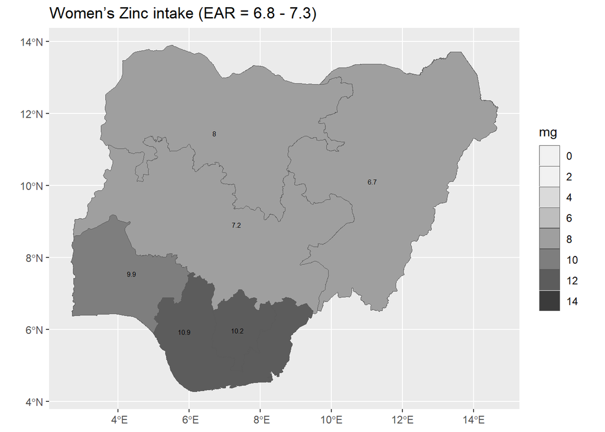

```r
ggplot(vect_gpz_geo_NFCMS) +
  geom_spatvector(aes(fill = ZINC_IN_W_75)) +
  geom_spatvector_text(aes(label = ZINC_IN_W_75), size = 2) +
  scale_fill_stepsn(
    n.breaks = 10,
    limits = c(0, 15),
    colours = hcl.colors(palette = "Grays", 10, rev = T),
    guide = "legend",
    na.value = "pink",
    labels = scales::comma
  ) +
  labs(title = "Women's Zinc intake (EAR = 6.8 - 7.3)", fill = "mg") +
  theme(
    plot.title = element_markdown(),
    legend.title = element_markdown(),
    axis.title = element_blank()
  )
```

Women’s zinc intake is highest in the southern zones.

The average intake is above the recommended intake for non-pregnant women in four zones, within the range for North Central, and below the recommended intake in North East

## Total Vitamin A intake

The NFCMS provides a list of the 10 food products that contribute most to Vitamin A intake for each zone. These data provide context to the macro-nutrient intake for each zone, and provide insights into the food basket composition for each zone.

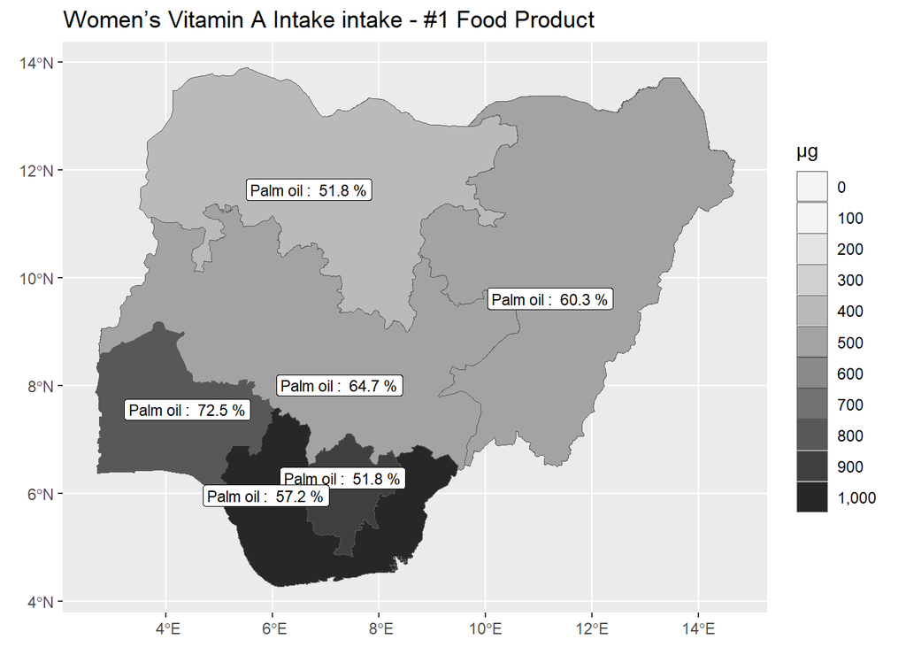

```r
ggplot(vect_gpz_geo_NFCMS_A25) +
  geom_spatvector(aes(fill = SN1_mcg)) +
  geom_spatvector_label(
    aes(label = paste(SN1_Name, ": ", SN1_pc, "%")),
    position = position_jitter(width = 0.1, height = 1.2, seed = 3),
    size = 3
  ) +
  scale_fill_stepsn(
    n.breaks = 10,
    limits = c(0, 1000),
    colours = hcl.colors(palette = "Grays", 10, rev = T),
    guide = "legend",
    na.value = "pink",
    labels = scales::comma
  ) +
  labs(
    title = "Women's Vitamin A Intake intake - #1 Food Product",
    fill = "µg"
  ) +
  theme(
    plot.title = element_markdown(),
    legend.title = element_markdown(),
    axis.title = element_blank()
  )
```

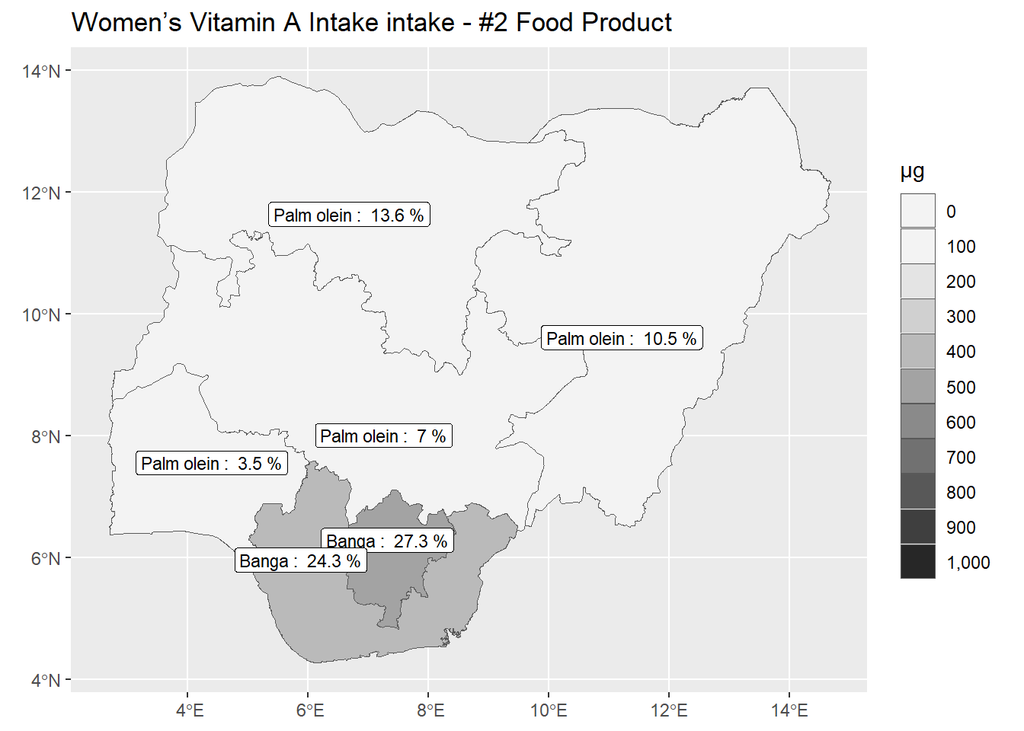

```r
ggplot(vect_gpz_geo_NFCMS_A25) +
  geom_spatvector(aes(fill = SN2_mcg)) +
  geom_spatvector_label(
    aes(label = paste(SN2_Name, ": ", SN2_pc, "%")),
    position = position_jitter(width = 0.1, height = 1.2, seed = 3),
    size = 3
  ) +
  scale_fill_stepsn(
    n.breaks = 10,
    limits = c(0, 1000),
    colours = hcl.colors(palette = "Grays", 10, rev = T),
    guide = "legend",
    na.value = "pink",
    labels = scales::comma
  ) +
  labs(
    title = "Women's Vitamin A Intake intake - #2 Food Product",
    fill = "µg"
  ) +
  theme(
    plot.title = element_markdown(),
    legend.title = element_markdown(),
    axis.title = element_blank()
  )
```

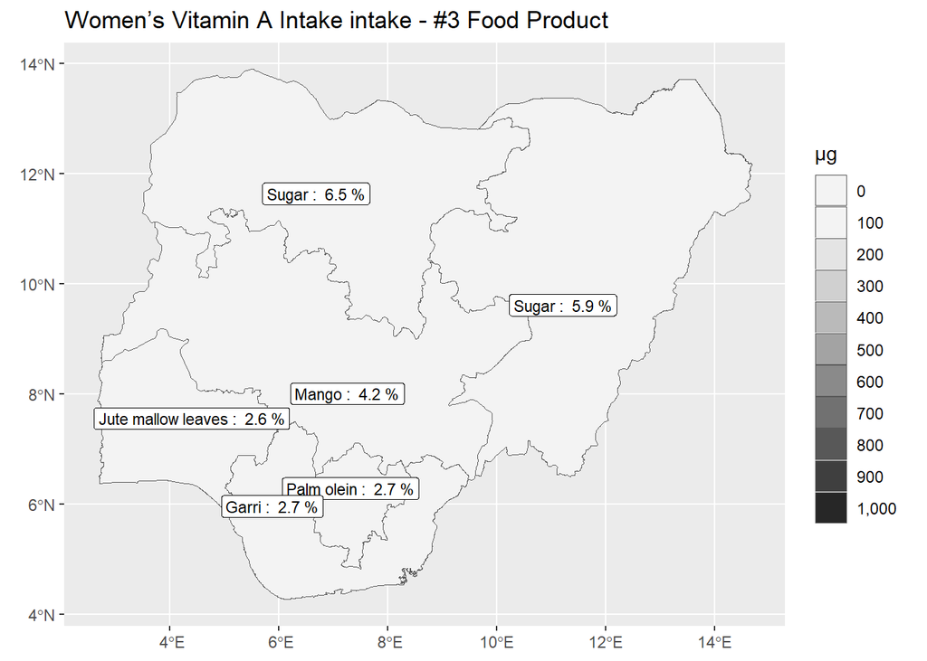

```r
ggplot(vect_gpz_geo_NFCMS_A25) +
  geom_spatvector(aes(fill = SN3_mcg)) +
  geom_spatvector_label(
    aes(label = paste(SN3_Name, ": ", SN3_pc, "%")),
    position = position_jitter(width = 0.1, height = 1.2, seed = 3),
    size = 3
  ) +
  scale_fill_stepsn(
    n.breaks = 10,
    limits = c(0, 1000),
    colours = hcl.colors(palette = "Grays", 10, rev = T),
    guide = "legend",
    na.value = "pink",
    labels = scales::comma
  ) +
  labs(
    title = "Women's Vitamin A Intake intake - #3 Food Product",
    fill = "µg"
  ) +
  theme(
    plot.title = element_markdown(),
    legend.title = element_markdown(),
    axis.title = element_blank()
  )
```

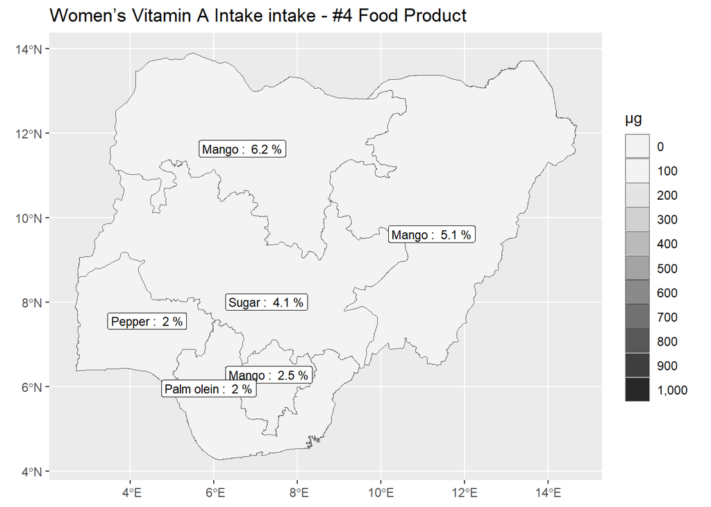

```r
ggplot(vect_gpz_geo_NFCMS_A25) +
  geom_spatvector(aes(fill = SN4_mcg)) +
  geom_spatvector_label(
    aes(label = paste(SN4_Name, ": ", SN4_pc, "%")),
    position = position_jitter(width = 0.1, height = 1.2, seed = 3),
    size = 3
  ) +
  scale_fill_stepsn(
    n.breaks = 10,
    limits = c(0, 1000),
    colours = hcl.colors(palette = "Grays", 10, rev = T),
    guide = "legend",
    na.value = "pink",
    labels = scales::comma
  ) +
  labs(
    title = "Women's Vitamin A Intake intake - #4 Food Product",
    fill = "µg"
  ) +
  theme(
    plot.title = element_markdown(),
    legend.title = element_markdown(),
    axis.title = element_blank()
  )
```

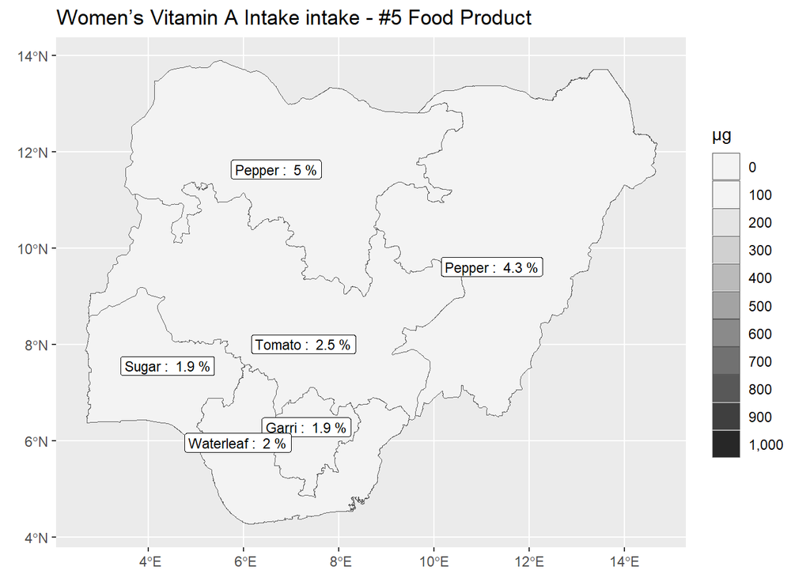

```r
ggplot(vect_gpz_geo_NFCMS_A25) +
  geom_spatvector(aes(fill = SN5_mcg)) +
  geom_spatvector_label(
    aes(label = paste(SN5_Name, ": ", SN5_pc, "%")),
    position = position_jitter(width = 0.1, height = 1.2, seed = 3),
    size = 3
  ) +
  scale_fill_stepsn(
    n.breaks = 10,
    limits = c(0, 1000),
    colours = hcl.colors(palette = "Grays", 10, rev = T),
    guide = "legend",
    na.value = "pink",
    labels = scales::comma
  ) +
  labs(
    title = "Women's Vitamin A Intake intake - #5 Food Product",
    fill = "µg"
  ) +
  theme(
    plot.title = element_markdown(),
    legend.title = element_markdown(),
    axis.title = element_blank()
  )
```

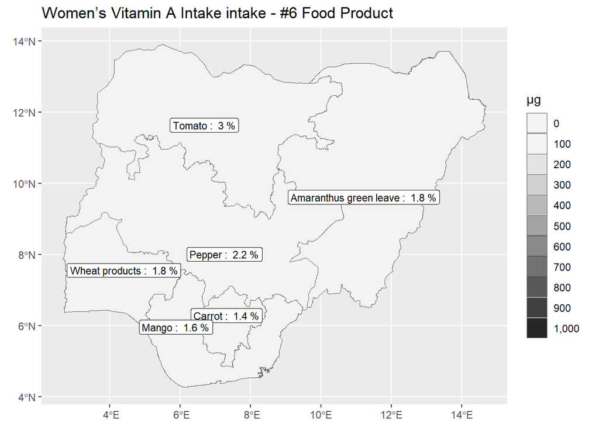

```r
ggplot(vect_gpz_geo_NFCMS_A25) +
  geom_spatvector(aes(fill = SN6_mcg)) +
  geom_spatvector_label(
    aes(label = paste(SN6_Name, ": ", SN6_pc, "%")),
    position = position_jitter(width = 0.1, height = 1.2, seed = 3),
    size = 3
  ) +
  scale_fill_stepsn(
    n.breaks = 10,
    limits = c(0, 1000),
    colours = hcl.colors(palette = "Grays", 10, rev = T),
    guide = "legend",
    na.value = "pink",
    labels = scales::comma
  ) +
  labs(
    title = "Women's Vitamin A Intake intake - #6 Food Product",
    fill = "µg"
  ) +
  theme(
    plot.title = element_markdown(),
    legend.title = element_markdown(),
    axis.title = element_blank()
  )
```

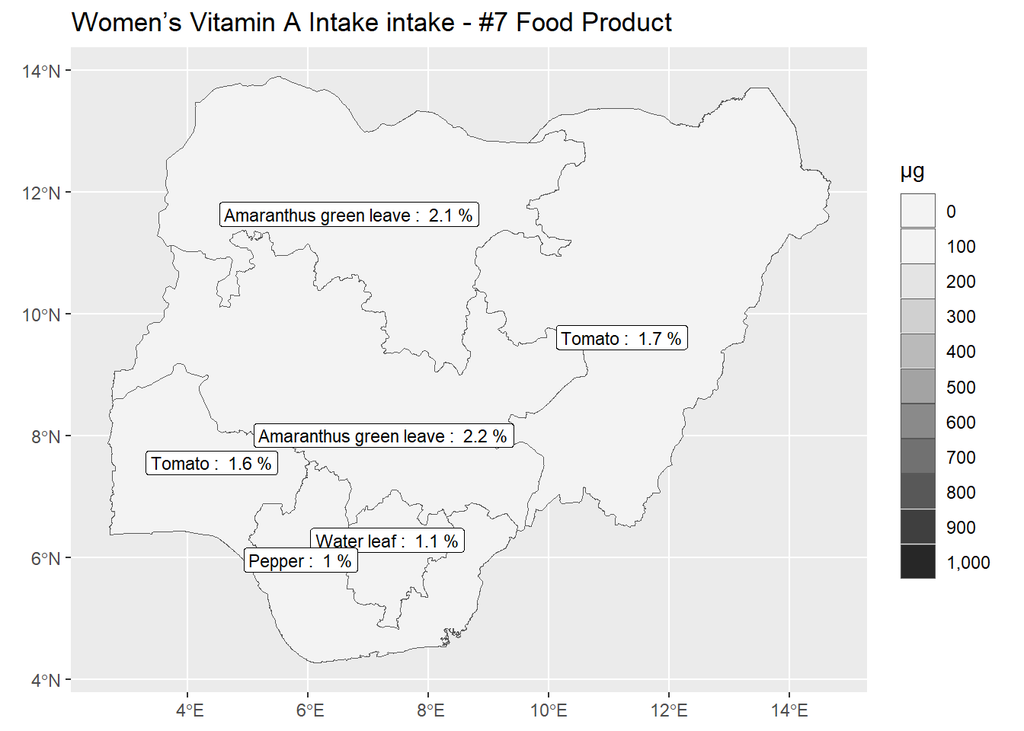

```r
ggplot(vect_gpz_geo_NFCMS_A25) +
  geom_spatvector(aes(fill = SN7_mcg)) +
  geom_spatvector_label(
    aes(label = paste(SN7_Name, ": ", SN7_pc, "%")),
    position = position_jitter(width = 0.1, height = 1.2, seed = 3),
    size = 3
  ) +
  scale_fill_stepsn(
    n.breaks = 10,
    limits = c(0, 1000),
    colours = hcl.colors(palette = "Grays", 10, rev = T),
    guide = "legend",
    na.value = "pink",
    labels = scales::comma
  ) +
  labs(
    title = "Women's Vitamin A Intake intake - #7 Food Product",
    fill = "µg"
  ) +
  theme(
    plot.title = element_markdown(),
    legend.title = element_markdown(),
    axis.title = element_blank()
  )
```

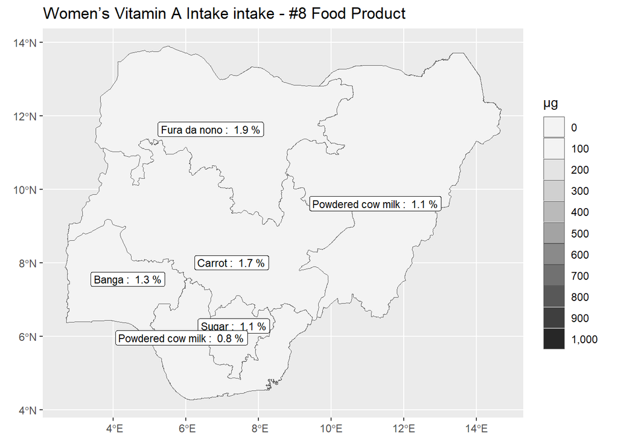

```r
ggplot(vect_gpz_geo_NFCMS_A25) +
  geom_spatvector(aes(fill = SN8_mcg)) +
  geom_spatvector_label(
    aes(label = paste(SN8_Name, ": ", SN8_pc, "%")),
    position = position_jitter(width = 0.1, height = 1.2, seed = 3),
    size = 3
  ) +
  scale_fill_stepsn(
    n.breaks = 10,
    limits = c(0, 1000),
    colours = hcl.colors(palette = "Grays", 10, rev = T),
    guide = "legend",
    na.value = "pink",
    labels = scales::comma
  ) +
  labs(
    title = "Women's Vitamin A Intake intake - #8 Food Product",
    fill = "µg"
  ) +
  theme(
    plot.title = element_markdown(),
    legend.title = element_markdown(),
    axis.title = element_blank()
  )
```

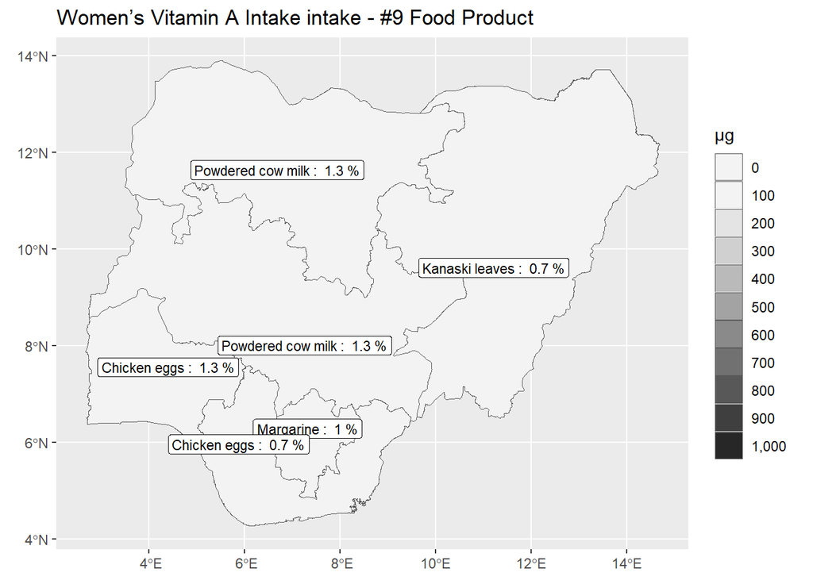

```r
ggplot(vect_gpz_geo_NFCMS_A25) +
  geom_spatvector(aes(fill = SN9_mcg)) +
  geom_spatvector_label(
    aes(label = paste(SN9_Name, ": ", SN9_pc, "%")),
    position = position_jitter(width = 0.1, height = 1.2, seed = 3),
    size = 3
  ) +
  scale_fill_stepsn(
    n.breaks = 10,
    limits = c(0, 1000),
    colours = hcl.colors(palette = "Grays", 10, rev = T),
    guide = "legend",
    na.value = "pink",
    labels = scales::comma
  ) +
  labs(
    title = "Women's Vitamin A Intake intake - #9 Food Product",
    fill = "µg"
  ) +
  theme(
    plot.title = element_markdown(),
    legend.title = element_markdown(),
    axis.title = element_blank()
  )
```

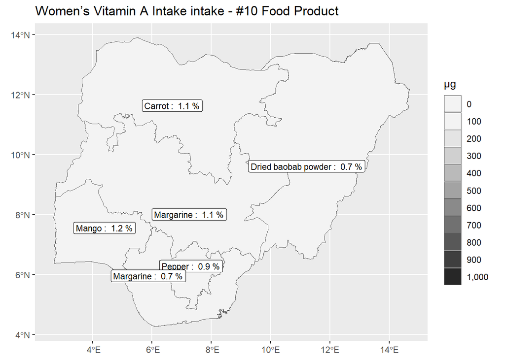

```r
ggplot(vect_gpz_geo_NFCMS_A25) +
  geom_spatvector(aes(fill = SN10_mcg)) +
  geom_spatvector_label(
    aes(label = paste(SN10_Name, ": ", SN10_pc, "%")),
    position = position_jitter(width = 0.1, height = 1.2, seed = 3),
    size = 3
  ) +
  scale_fill_stepsn(
    n.breaks = 10,
    limits = c(0, 1000),
    colours = hcl.colors(palette = "Grays", 10, rev = T),
    guide = "legend",
    na.value = "pink",
    labels = scales::comma
  ) +
  labs(
    title = "Women's Vitamin A Intake intake - #10 Food Product",
    fill = "µg"
  ) +
  theme(
    plot.title = element_markdown(),
    legend.title = element_markdown(),
    axis.title = element_blank()
  )
```

### Vitamin A intake (NFCMS, 2021)

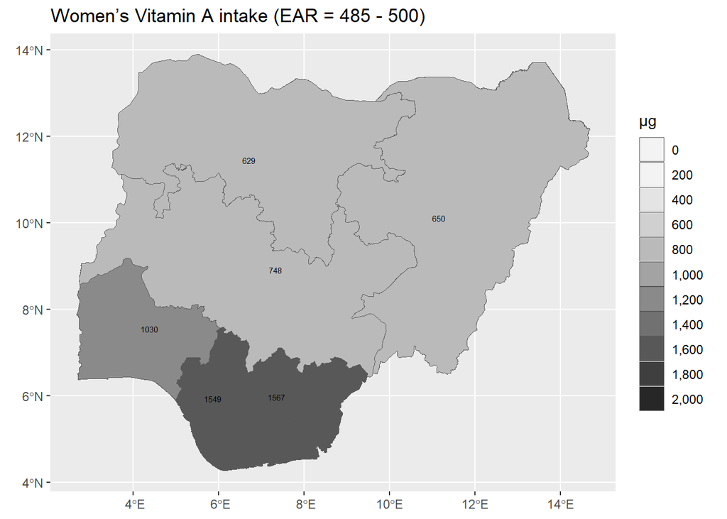

```r
ggplot(vect_gpz_geo_NFCMS) +
  geom_spatvector(aes(fill = VITA_IN_W_79)) +
  geom_spatvector_text(aes(label = VITA_IN_W_79), size = 2) +
  scale_fill_stepsn(
    n.breaks = 10,
    limits = c(0, 2000),
    colours = hcl.colors(palette = "Grays", 10, rev = T),
    guide = "legend",
    na.value = "pink",
    labels = scales::comma
  ) +
  labs(title = "Women's Vitamin A intake (EAR = 485 - 500)", fill = "µg") +
  theme(
    plot.title = element_markdown(),
    legend.title = element_markdown(),
    axis.title = element_blank()
  )
```

Women’s Vitamin A intake is again highest in the southern zones.

The average intake is above the recommended intake for non-pregnant women in all zones, however, the average vitamin A intake in South South and South East are over double the values in the three northern zones.